# 智能制造系统设计 · 第 4 讲：安全工程与环保工程

刘训臣

山东科技大学 机械电子工程学院

# 第〇部分 · 课程介绍与本讲定位

- 安全工程与环保工程：本讲 90 分钟、四个内容块
- 一条主线：**能量 → 危险源 → 事故树 → 责任 → 环境**
- 安全工程回答“人能不能不出事”，环保工程回答“事做完环境付什么代价”；落点：安全事故与责任事故、环境成本由谁承担
- 工具：海因里希法则、LEC、FTA、事故树布尔化简、三废治理、碳达峰碳中和
- **承上**：第 3 讲用工业工程与精益生产收束“效率”；本讲转入效率之外的两个代价——安全与环境，先交代内容块、课程位置、时间安排与考试口径。

## 第 4 讲：教学内容与主线（内容块 1–2）

**内容块 1 · 安全工程基础**

- 安全工程的对象与四个基本概念：职业健康安全、安全生产、劳动保护、危险源
- 事故的定义与四级分类，20 类致伤原因；**海因里希法则** 1 : 29 : 300
- 伤亡事故统计指标；事故致因理论：因果连锁、**能量意外释放论**与两类危险源

**内容块 2 · 风险评估与事故树 FTA**

- 风险评估链条：危险源辨识 → 风险评价 → 控制措施
- 安全检查表 SCL、**LEC 作业条件危险性评价**（$D=LEC$：$D$ 危险性分值、$L$ 事故可能性、$E$ 暴露频繁程度、$C$ 后果严重度，均无量纲）
- **事故树**：六类事件、逻辑门、建树程序；布尔代数化简与等效事故树
- **最小割集／最小径集**、结构重要度、顶事件概率计算

## 第 4 讲：教学内容与主线（内容块 3–4）

**内容块 3 · 安全责任与智能制造安全**

- 《建设工程安全生产管理条例》五方责任划分
- **安全事故 vs 安全责任事故**：判定逻辑与责任追究（直接／主要领导／重要领导）
- 智能制造的新风险：人机协作、网络与数据、算法决策
- 安全网络与 AI 实时分析；人员行为特征挖掘与防呆设计

**内容块 4 · 环保工程**

- 工程与环境：环境友好型工程、环保运动、《寂静的春天》与地球日
- 环保法规、**环境影响评价**与“三同时”、清洁生产
- 废气、废水、固废治理技术；绿色制造与**碳达峰碳中和**
- 环境成本由谁承担；环评与公众知情

## 教学进度 · 10 次课全览

> 上一页给完内容块 3、4；这一页把本讲放进十次课全景。

| 次 | 模块 | 主题 |
| --- | --- | --- |
| 1 | 导论与 3.1 | 课程导论、工程与社会与质量工程（一）：国家战略、工程的社会属性、质量管理基础 |
| 2 | 3.1 | 质量工程（二）与质量工具：五大工具 APQP／FMEA／MSA／SPC／PPAP、CPK、QC 七大手法 |
| 3 | 3.2 | 工业工程与精益生产（＋实验 2 课时：线性规划与工业工程例子） |
| **4** | **3.3、3.4** | **安全工程与环保工程：海因里希法则、事故树 FTA、风险评估、三废治理、双碳** |
| 5 | 3.5、3.6 | 成本管理与人力资源：成本构成、投资回收期、NPV／IRR、质量成本、人才与激励 |
| 6 | 4.1～4.3 | 企业信息系统（一）：ERP、MES、PLM 与系统集成全景 |
| 7 | 4、6 | 企业信息系统（二）与 8D：CRM／WMS／APS，8D 八步与软件开发流程 |
| 8 | 工程伦理（一） | 工程事故与伦理准则：凯悦酒店、NSPE 准则、伦理决策框架 |
| 9 | 工程伦理（二） | 风险、安全与责任，工程师与组织：责任判定、组织文化与信任 |
| 10 | 伦理（三）与综合 | 技术的社会意义、国际化、AI 伦理；智能设计应用、前沿、课程设计与总复习 |

**结论：本讲是第 4 次课、模块 3.3 与 3.4，前接效率、后接成本。**

## 本讲在课程中的位置

**第 3 讲**解决了“效率”：用 IE 与精益消除浪费、提高产出。

**第 4 讲**回答两个约束问题：

- **安全约束**：效率提高不能以人的伤亡为代价——事故的代价如何度量、如何预防、由谁担责
- **环境约束**：产出增加不能以环境破坏为代价——三废从哪来、怎么治、成本谁承担

**一条贯穿的计算链**：

- 事故 → 能量失控 → 危险源 → 事故树 → 最小割集 → 顶事件概率 → 控制措施
- 排放 → 污染源 → 治理工艺 → 达标排放 → 环境成本 → 绿色制造

> 如果说质量是“满足要求”，安全就是“不突破底线”，环保是“不透支未来”。

## 安全与环保在智能制造中的位置

> 上一页把本讲放进十次课；这一页回答智能制造为什么还要学安全环保。

| 维度 | 传统制造 | 智能制造 | 本讲落点 |
| --- | --- | --- | --- |
| 风险源 | 机械、电气、化学品 | 人机协作、储能、网络与算法 | 两类危险源、能量法 |
| 管理方式 | 静态检查、事后调查 | 传感＋数据＋AI 的动态安全网络 | 静态—动态—实时 |
| 责任主体 | 企业与操作者 | 加上算法供应商、集成商、数据方 | 责任事故判定 |
| 环境约束 | 末端治理、达标排放 | 全过程清洁生产、碳达峰碳中和 | 环评与三废 |

- 本讲的判断：安全工程贯穿智能制造全生命周期（设计、生产、设备运维、废弃处理），以能量为核心
- 顶层按“设备→环境→人”设计，实施按“工亡→工伤→质量→效率”
- 环保同构：先合规（环评、三同时）→ 再减量（清洁生产）→ 末端治理与碳管理

## 安全工程的一条主线：能量

> 上一页讲清四个维度的变化；这一页给出贯穿全讲的一个统一视角——能量。
- 任何安全事故都伴随**能量的异常释放**：机械动能、电能、热能、化学能、势能
- 正常生产 = 能量按设计路径受控流动；事故 = 能量越过了约束
- 于是安全工程的全部工作可以归为三件事：

| 环节 | 要问的问题 | 典型手段 |
| --- | --- | --- |
| 识别 | 系统里有哪些能量、哪些危险源？ | 危险源辨识、安全检查表 |
| 评价 | 失控的可能性和后果有多大？ | LEC、事故树、模糊综合评价 |
| 控制 | 如何约束能量、屏蔽能量？ | 工程技术、教育、强制（3E） |

- 智能制造让能量网络更复杂：机器人、自动化线、储能、网络与数据都成了新的能量与风险载体

**结论：安全只有一个根，就是能量有没有被约束住。**

## 本讲伦理与社会落点

> 上一页收在能量；这一页先把本讲的伦理与社会问题挂出来，后文逐个落地。
- **落点一：安全事故 vs 安全责任事故**——同样死了人，为什么有的追刑责、有的只算意外？
- **落点二：责任划分**——建设单位、设计、施工、监理，谁该为一条命负责？
- **落点三：环境成本由谁承担**——企业排污的代价，为什么常常由下游居民和下一代承担？
- **落点四：环评与公众知情**——谁有权在项目开工前知道它有多脏、多险？

| 技术场景 | 伦理问题 | 讨论页 |
| --- | --- | --- |
| 天津港 8·12、泉州欣佳酒店 3·7 | 违法建设与监管失守，责任如何判定 | 第三部分 |
| 松花江 2005 苯污染 | 环境损害的外部性由谁买单 | 第四部分 |

**结论：安全与环保的技术结论，最后都要落到“谁负责、谁付代价”。**

## 本讲 90 分钟怎么安排

> **90 分钟 ＝ 6 分钟开场回顾 ＋ 22＋22＋14＋12 分钟讲授 ＋ 8 分钟讨论 ＋ 6 分钟收尾。**

| 序 | 时间块 | 讲什么 | 分钟 |
| --- | --- | --- | --- |
| 0 | 开场与第 3 讲回顾 | 六问自测 | 6 |
| 1 | 安全工程基础 | 分级、统计、能量论 | 22 |
| 2 | 风险评估与事故树 | LEC、化简、割集 | 22 |
| 3 | 安全责任与智能安全 | 五方责任、安全网络 | 14 |
| 4 | 环保工程 | 环评、三废、双碳 | 12 |
| 5 | 讨论与例题 | 指标、割集、投入 | 8 |
| 6 | 小结与作业 | 小结、作业、预告 | 6 |

- 四个讲授块 70 分钟：算风险 44 → 分责任 14 → 治环境 12，先算清再判断
- 时间紧先压事故统计细节与三废工艺参数；**事故树化简、责任事故判定、环评三同时**不能压
- 安全工程基础 22 分钟含 GJB 六性 2 分钟（只讲六性表与“可验证条款”），联锁只作一句引子，完整案例课后读

## 学习目标与能力清单：五个可检查的动作

> **五条能力＝五个动作：分得清等级、算得出风险、画得出树、判得清责任、选得对工艺。**

| 能力 | 具体要求 | 落点 | 验收标准（可检查） |
| --- | --- | --- | --- |
| 能分级 | 事故四级划分、三个统计指标 | 第一部分 | 1200 人、$2.4\times10^{6}$ h → 0.83、1.67、6.25，判一般事故 |
| 能算风险 | LEC 打分分级；集对分析、AHP | 第二部分 | $3\times6\times15=270$ 判高度危险，说出降 L／E／C 三条路 |
| 能画树 | 六类事件、五种门、化简、最小割集 | 第二、五部分 | 给一张树，10 分钟写式、化简、列割集、算 $P(T)$ |
| 能判责 | 安全事故与安全责任事故；五方责任 | 第三部分 | 给一份事故通报，指出责任主体、依据与追责层级 |
| 能治污 | 三废路线、环评与三同时、双碳 | 第四部分 | 画一条治理路线，说明各段去除什么、成本谁承担 |

- 五条里三条靠算、两条靠判断；验收标准一律写成可检查的动作，不写“理解”“掌握”
- 知识—能力—素养三层：概念与法规是知识，画与算是能力，**代价由谁承担**是素养

**结论：三条靠算、两条靠判断，五条都要能在纸上做出来。**

## 考试视角：本讲真题分布

| 考点 | 题型 | 出现卷次 | 备考口径 |
| --- | --- | --- | --- |
| 事故树化简＋等效树 | 第四题，10 分 | 六卷全有 | 写式→化简→画树，练到手熟 |
| LEC 风险评价 | 未出题 | 六卷均无 | 会算 $D=LEC$、会分级 |
| 事故等级与统计指标 | 未出题 | 六卷均无 | 会算三个率、会判级 |
| 安全与责任事故判定 | 未出题 | 六卷均无 | 能写 300 字判据 |
| 三废、环评、双碳 | 未出题 | 六卷均无 | 能画路线、说清责任 |
| 体系归属 | 单选 3 分（B 卷） | 2020B、2021B、2022B | 9000 质量、14000 环境、18000 安全（18001 已由 ISO 45001／GB/T 45001 取代，答题写新号并注明） |

- 固定三步：写式 → 化简 → 画等效树；图由试卷给出
- 判分点：与门乘、或门加；吸收律 $A+AB=A$；报最小割集
- 复习优先级：事故树 10 分必拿＞事故等级＞环保；第四题 15 分钟
- 必考：六卷里本讲各占 10 分；未出题部分按简答、论述准备

## 本讲路线图与课前准备

> **主线：度量 → 计算 → 判责 → 治污；从“出多大的事”走到“谁来付代价”。**

| 部分 | 入口问题 | 讲什么 | 出口 |
| --- | --- | --- | --- |
| 一 · 安全工程基础 | 事故怎么度量 | 四个概念、四级分级、海因里希、能量论 | 指标算得出 |
| 二 · 风险评估与 FTA | 风险怎么算 | SCL、LEC、集对分析、AHP、事故树 | 树画得出、化简对 |
| 三 · 安全责任与智能安全 | 出事谁负责 | 五方责任、责任事故、安全网络与 AI | 责任说得清 |
| 四 · 环保工程 | 代价谁承担 | 环评与三同时、三废、清洁生产、双碳 | 工艺选得对 |
| 五 · 例题与讨论 | 会不会用 | 统计指标、最小割集、安全投入 | 题做得完 |

- 复习第 3 讲六问；带计算器、A4 纸与直尺——事故树与等效树都要手画
- 预习 3.3 节与环保课件：六类事件、五种门、海因里希法则；不懂的一处写在纸上
- 本讲无实验课时；练习放在作业与第 5 讲“成本与安全的取舍”案例中

## 第 3 讲回顾与检查：六个问题

> **1 分钟开场、5 分钟六问：答不出的那一条，就是今天要补的地基。**

| 问题 | 一句话答案 | 今天怎么用 |
| --- | --- | --- |
| ① ECRS 四原则？ | 取消、合并、重排、简化 | 化简也在“取消”冗余事件 |
| ② 8 大浪费？ | DOWNTIME 八类，含人才未利用 | 浪费的代价最终进成本 |
| ③ 标准工时？ | $6.00\times1.05\times1.12=7.056$ min，8.50 件/h | 整改方案也要算工时与停线损失 |
| ④ 线平衡率？ | $340/(75\times5)=90.7\%$，空闲 35 s | 改善先找瓶颈，整改也一样 |
| ⑤ 鱼骨图？ | 人机料法环五支，圈主因、配措施 | 鱼骨横向归类，事故树纵向追因 |
| ⑥ 线性规划？ | 变量、目标、约束；最优 (40,20)，$z=2200$ | 安全投入的最小费用也是 LP |

- 六问分三类：①② 是“消除浪费”，③④⑥ 是“算”，⑤ 是“找原因”；今天把对象从效率换成风险与环境
- 抽查：随机点两人各答一问；答不出不扣分，课后补，下次课前再问
- 接第 2 讲军标拓展的六性（GJB 450A 等）——与本节安全要求同一套思路：指标＋验证方法＋合格判据。

## 产教融合 · 本讲企业真题：从隐患台账到最小割集

> **企业场景：**企业齿轮磨削工序曾发生冷却液中断、防护罩缺失下的灼伤未遂；隐患台账记录 3 类 11 条。

| 企业真实问题 | 本讲工具 | 学生产出 |
| --- | --- | --- |
| 顶上事件“磨削灼伤”路径不清，控制措施停留在“加强培训” | 事故树 FTA、布尔化简、最小割集/径集、LEC | 事故树与风险控制表（作业 3） |

- **教案对应：**第三章 3.3 安全工程；**企业参与：**安环部提供隐患台账与事故案例
- **验收：**事故树逻辑门与布尔化简正确；控制措施按本质安全优先顺序排列。

# 第一部分 · 安全工程基础

- 安全工程的研究对象：生产、生活中的事故；四个基本概念（职业健康安全、安全生产、劳动保护、危险源）
- 两条定量工具：事故分级与统计指标、海因里希法则
- 一条理论主线：事故致因 → 能量意外释放 → 两类危险源
- 本部分落点：把“安全第一”从口号变成可度量的指标
- **承上**：上一部分（第〇部分）给出本讲主线与时间安排；本部分要回答“安全用什么语言描述”——对象、分级、统计与致因理论。

## 安全工程是什么：对象与四个基本概念

> 上一页给出本部分主线；这一页回答四个基本概念怎么分工。
- **是什么**：以生产、生活中的事故为对象，综合技术与管理科学，识别并控制不安全因素的知识体系。
- **研究对象**：生产事故、工业产品安全、重大工业事故、生活安全四类。

| 概念 | 含义 | 怎么判断 |
| --- | --- | --- |
| 职业健康安全 | 用管理体系减少人身、财产、时间损失 | 有 ISO 45001 体系并运行 |
| 安全生产 | 人、设备、环境、产品安全性的全面保障 | 人身与设备都不出事 |
| 劳动保护 | 保障劳动者安全健康的法律制度 | 以《劳动法》为核心 |
| 危险源 | 伤害、损失、环境破坏的根源 | 能指出能量与失效点 |

- **为什么**：四者分别回答“管什么、到什么状态、靠什么制度、根源在哪”。
- **怎么判断**：看一项工作落在哪一层——体系、状态、制度还是根源。

**结论：四个概念分四层，判断工作先看它落在哪一层。**

## 安全、危险、风险与事故：四个词

> 上一页把四个基本概念按层分开；这一页区分安全、危险、风险与事故四个近义词。
- **安全**：风险被控制在可接受水平的状态，不是“零危险”
- **危险**：系统中客观存在、可能造成伤害的属性，先于事故存在
- **风险**：伤害发生的可能性与后果严重度的组合，$R=L\times S$，其中 $R$ 为风险值（无量纲等级）、$L$ 为可能性、$S$ 为后果严重度
- **事故**：违反人的意志、迫使活动暂时或永久停止的突发事件
- 四者关系：危险是源，风险是量，事故是果，安全是被管住的风险
- 状态演进：安全（可接受）→ 危险（不可接受但尚未发生）→ 事故（能量释放）
- 未遂事故：没有伤害也没有损失的事故，是最廉价的一次预警

## 事故的定义与分类

> 上一页把四个词分开；这一页按法规口径把事故与伤害分档。
- **事故**：人在实现意图的活动中，突然发生、违反意志、迫使活动暂时或永久停止的事件
- **伤亡事故**：损失工作日达到或超过 1 天的人身伤害或急性中毒
- **工伤事故**：生产区域内发生的、与生产有关的伤亡事故
- **未遂事故**：无伤害、无损坏、无污染的事故——**最廉价的预警信号**
- **伤害三档**：轻伤 <105 日；重伤 ≥105 日；死亡按 6000 个损失工作日折算
- **怎么判断**：先看有没有损失工作日，再看是否与生产有关，最后看是不是“差点出事”
- 判据：只统计“已发生的伤害”，就会把最便宜的情报（未遂）丢掉

## 事故等级：四级划分

> 上一页给出伤亡事故的法规口径；这一页按后果把事故分成四级。

| 等级 | 死亡人数 | 重伤人数 | 直接经济损失 | 调查主体 |
| --- | --- | --- | --- | --- |
| 特别重大 | 30 人以上 | 100 人以上 | 1 亿元以上 | 国务院 |
| 重大 | 10～30 人 | 50～100 人 | 5000 万～1 亿元 | 省级政府 |
| 较大 | 3～10 人 | 10～50 人 | 1000 万～5000 万元 | 地市级政府 |
| 一般 | 3 人以下 | 10 人以下 | 1000 万元以下 | 县级政府 |

- **怎么判断**：死亡、重伤、直接经济损失**三个条件满足其一**即按较高等级认定；间接损失不计入
- 边界口径：“以上”含本数、“以下”不含本数，考试常在此设坑
- 判据：等级决定调查主体与追责层级，先定级再谈责任

## 伤亡事故统计指标

- **为什么**：只用死亡人数无法比较不同规模的企业，必须用**相对指标**
- 四个指标：千人死亡率、千人重伤率、百万工时伤害频率、伤害严重率

公式

- 千人死亡率 $=\dfrac{死亡人数}{平均职工人数}\times 10^{3}$；千人重伤率同式
- 百万工时伤害频率 $=\dfrac{伤害人数}{实际总工时}\times 10^{6}$；伤害严重率用总损失工作日
- **怎么判断**：分母看口径——千人率用平均职工人数，百万工时率用实际总工时，不能混用
- 算例：2000 人、死亡 1、重伤 3、轻伤 40、总工时 $4.0\times10^{6}$ h：$1/2000\times10^3=0.5$‰、$3/2000\times10^3=1.5$‰、$(1+3+40)/(4.0\times10^6)\times10^6=11$ 人次/百万工时
- 判据：伤害人数含死亡；只报死亡数会低估风险

## 事故的四本账：生命、财产、生产、社会

> 上一页算出相对指标；这一页回答事故的代价怎么计量。

| 账本 | 直接表现 | 计量口径 |
| --- | --- | --- |
| 生命账 | 死亡、重伤、职业病 | 损失工作日，死亡按 6000 日折算 |
| 财产账 | 设备、厂房、物料损毁 | 直接经济损失（GB 6721） |
| 生产账 | 停产、违约、供应链中断 | 停产天数 × 日产值 |
| 社会账 | 信任流失、监管加严、行业整顿 | 难以货币化，但真实发生 |

- 一条命折算 6000 个损失工作日，相当于 24 人年（按 250 工作日／年）
- 一次性工亡补助金为上一年度全国城镇居民人均可支配收入的 20 倍
- 财产账看得见；生产账与社会账常常数倍于财产账
- 代价的承担者不止企业：员工家庭、客户、周边居民、监管部门
- 判据：只算直接损失，必然低估安全投入的回报

## 20 类事故：统计口径与现场高频

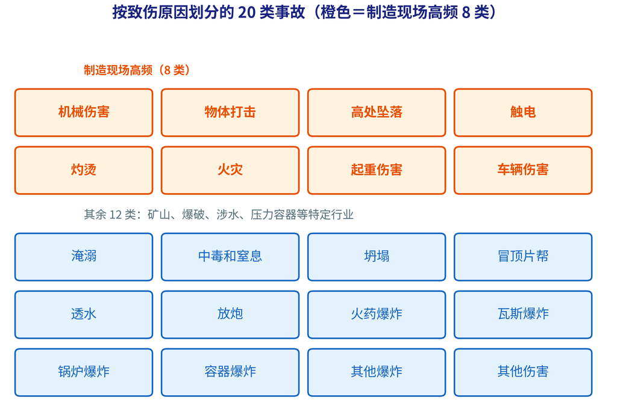

- **是什么**：GB 6441 按**致伤原因**分 20 类，是统计与原因分析的口径
- **怎么判断**：按**主要原因**归一类，不按后果归一类
- 高频八类：机械伤害、物体打击、高处坠落、触电、灼烫、火灾、起重伤害、车辆伤害

## 海因里希法则：1 : 29 : 300

> 上一页把事故按致伤原因分成 20 类；这一页回答最常用的 1 : 29 : 300 怎么用。

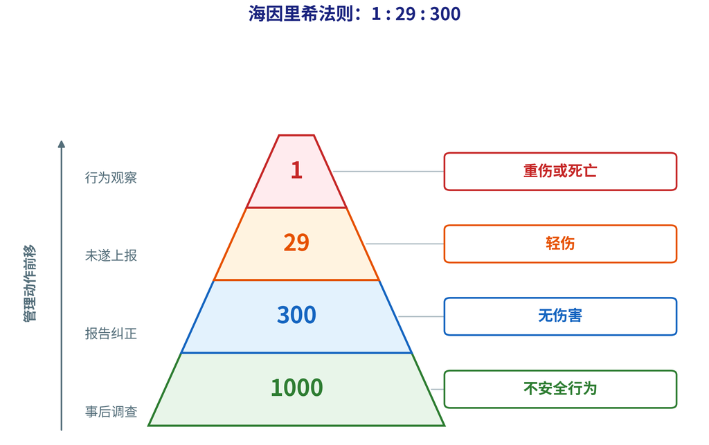

**结论：安全投入要花在 300 与 1000 这一层——抓未遂与违章，而不是等事故后追责。**

## 事故致因理论的三代演进

| 阶段 | 代表理论 | 核心主张 | 预防落点 |
| --- | --- | --- | --- |
| 单因素（20 世纪初—1940 年代） | 事故频发倾向论 | 少数人天生易出事故 | 筛人、换人 |
| 多因素（1950—1970 年代） | 因果连锁、能量意外释放、轨迹交叉 | 人、物、能量多因素耦合 | 断链、屏蔽能量 |
| 系统（1980 年代至今） | 瑞士奶酪、系统安全、STAMP | 组织与防御层的缺陷 | 纵深防御、组织学习 |

- 主线：从“找罪人”到“找缺陷”，再到“找系统”
- 单因素论已被证伪：事故率差异主要来自岗位暴露，不是人的天性
- 三代不是替代关系：现场分析仍以因果连锁与能量论为主
- 每代回答的是同一问题的不同侧面：为什么偏偏是这一次
- 判据：理论选错，措施就只剩“多培训、多罚款”

## 3E 对策：工程优先、教育其次、强制兜底

> 上一页五块骨牌里第三块是抓手；这一页回答这个抓手怎么排。
- **是什么**：事故预防的三类对策——工程技术（Engineering）、教育（Education）、强制（Enforcement）
- **为什么**：人一定会犯错；教育只能降低犯错概率，工程才能消除犯错后果

| 对策 | 做法 | 车间例子 |
| --- | --- | --- |
| 工程技术 | 从设备与工艺上消除危险 | 冲压机光电保护、机器人围栏 |
| 教育 | 让员工知道风险与规程 | 三级安全教育、特种作业培训 |
| 强制 | 用制度与法规约束行为 | 安全帽佩戴、动火作业票 |

- **怎么判断**：看措施落在哪一层；能用工程消除的，不要靠教育和罚款去“管人”
- 判据：顺序颠倒（先罚人、后改设备）是最常见的安全管理错位

## 轨迹交叉论：两条链在哪里相交

> 上一页的 3E 给出措施的优先序；这一页回答事故为什么偏偏在某一点撞上。
- 人的失误自成一条轨迹：生理、心理、技能、态度、管理
- 物的缺陷自成一条轨迹：设计、制造、维护、防护缺失
- 两条轨迹平时平行，在时间与空间上交叉的那一点就是事故
- 交叉需要同时同地：任一条轨迹被推迟或移开，事故就不发生
- 第一路预防：避免交叉——人车分流、隔离围栏、错时作业
- 第二路预防：切断单条轨迹——消除物的缺陷，或纠正人的行为
- 与能量论的分工：能量论解释为什么受伤，轨迹交叉解释为什么撞上
- 现场典型：叉车通道与行人通道共用一段地面，就是交叉点

**结论：事故发生在两条轨迹的交叉点，预防要么错开、要么切断。**

## 瑞士奶酪模型：防御为何层层失效

> 上一页的轨迹交叉看两条线怎么相交；这一页看几层防御为何同时漏。
- 1990 年 Reason 提出：事故是各层防御的漏洞同时对齐的结果
- 四层防御：组织影响 → 不安全监督 → 不安全行为的前提 → 不安全行为
- 每层都有孔：制度缺口、监督缺位、疲劳与设备不良、差错与违章
- 孔是动态的：一次赶工、一次裁员，就会让某一层的孔变大
- 事故不是最后一层出错，而是所有层同时失效
- 启示一：加层（冗余）比加严（处罚）更可靠
- 启示二：漏洞靠报告发现，瞒报等于蒙上眼睛
- 与因果连锁的分工：一个是线性链，一个是并行防御面

## 能量意外释放论：两类危险源

> 上一页的瑞士奶酪说明防御会同时失效；这一页回到能量，把危险源分成两类来管。

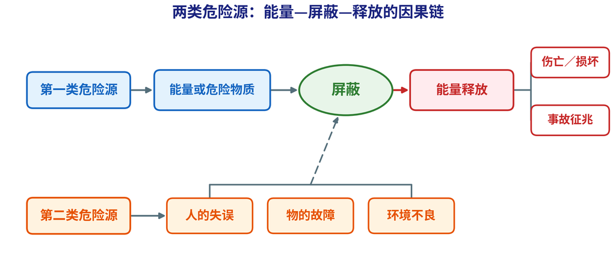

- **第一类危险源**：系统中的能量或危险物质（滑块动能、带电体、高温、可燃物），对策是降量、隔离、屏蔽。
- **第二类危险源**：导致能量失控的因素（人的失误、设备故障、环境不良、管理缺陷），对策是防错、冗余、监控。
- **怎么判断**：看到设备先问“能量是什么”，再问“约束靠什么、哪里会失效”。
- 控制顺序：先控第一类（能量本身），再控第二类（约束失效）。

**结论：事故＝能量未被约束；先管住能量本体，再堵住让约束失效的漏洞。**

## 能量意外释放论：事故的物理本质

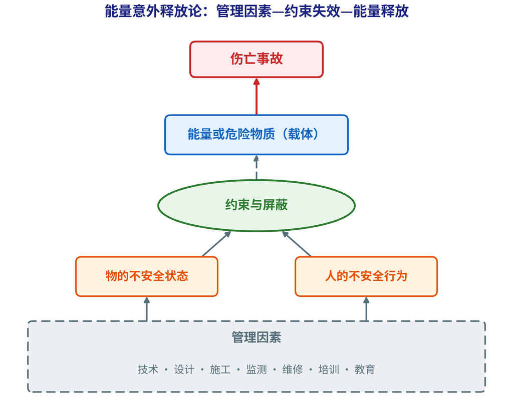

*三层因果：管理因素 → 人与物的失效 → 能量释放与伤亡*

- 正常生产：能量按设计路径流动、转换、做功；事故：能量失去约束、越界释放
- 伤害判据：释放的能量作用于人体且超过承受能力
- 控制顺序：先降能量总量与危害性质，再控约束失效（隔离、屏蔽、联锁）

## 危险三角形：危险元素、目标与威胁、触发机制

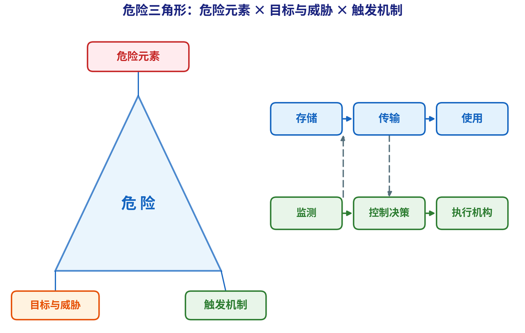

- **是什么**：最低层次的安全分析答三件事——危险元素、威胁谁、靠什么触发
- **怎么判断**：三者同时成立才成事故，切断任一要素即可预防
- 分层：全过程分区域 → 中间过程分块 → 最低层次分类，实现全覆盖

## 人的不安全行为与物的不安全状态

> 上一页的三角形三要素落到班组；这一页回答直接原因怎么归、根原因往哪追。

| 类别 | 典型表现 | 现场例子 |
| --- | --- | --- |
| 人的不安全行为 | 违章操作、忽视警告、用手代替工具 | 短接光栅、跨越护栏 |
| 物的不安全状态 | 防护缺失、设备缺陷、布局不合理 | 皮带轮无罩、通道堆料 |
| 管理缺陷 | 制度缺失、培训不足、隐患未整改 | 动火票代签、整改超期 |

- 人与物两类是事故的直接原因，管理缺陷是共同的上游
- 行为受物诱导：通道堆了料，人就必然跨栏
- 物受管理支配：防护罩被拆，理由往往是“影响效率”
- 统计口径：直接原因归人／物，根原因必须追到管理
- 防呆优先：让错误动作做不成，比提醒“注意安全”可靠

## 危险源辨识：从两类到三类

> 上一页把人、物、管理分开；这一页把管理补成第三类危险源。
- 第一类：系统中的能量或危险物质本身，如动能、电能、化学能
- 第二类：导致约束失效的因素，人的失误、物的故障、环境不良
- 第三类：管理缺陷，制度、培训、监督、投入的缺失
- 常用两类口径；三类口径把管理缺陷单列，追根因时更好用
- 辨识顺序：先找能量，再找约束，最后查管理
- 方法：对照法（标准、检查表）与系统分析法（HAZOP、FMEA、FTA）
- 判据：只列设备不列管理，辨识只做了一半

## 重大危险源：临界量与分级

> 上一页的辨识里最要紧的是固有能量大的单元；这一页回答什么算重大危险源。
- **是什么**：按 GB 18218 辨识，危险化学品数量达到或超过**临界量**的单元
- **单元**：一套装置设施，或同一单位边缘距离小于 500 m 的几套
- **分级**：一级、二级、三级、四级，一级最高
- **怎么判断**：看储量是否达到临界量，不看“危险不危险”
- 判据：重大危险源是**固有能量**，建起来就在那里；重大隐患才是控制失效

## 重大危险源：备案、监控与演练

> 上一页定出重大危险源的分级；这一页回答定级后必须办的四件事。
- 备案：安全评估报告完成后 **15 日**内报县级应急管理部门
- 重新评估：满 **3 年**，或装置、工艺、品种、数量发生变化
- 监控：不间断采集与泄漏报警；一级、二级配紧急停车与独立的安全仪表系统（SIS）
- 演练：专项预案每年至少 1 次，现场处置方案每半年至少 1 次
- **怎么判断**：四个数字——500 m（单元）、15 日（备案）、3 年（重评）、半年（演练）
- 判据：备案与演练记录是监管检查的第一份证据

## 职业危害因素：粉尘、噪声与毒物

> 上一页的重大危险源管的是突发释放；这一页转到长期暴露这条线。
- **是什么**：三类——化学（粉尘、毒物）、物理（噪声、振动、高温）、生物
- 粉尘：矽尘、煤尘、有机粉尘；游离二氧化硅越高，尘肺风险越大
- 噪声：8 h 等效声级 **85 dB(A)** 是职业接触限值；长期暴露损伤听力与心血管
- 毒物：苯、铅、汞、一氧化碳，主要经呼吸道进入，也可经皮肤吸收
- **怎么判断**：看控制顺序落在哪一层——替代 → 变更工艺 → 隔离 → 通风 → 个体防护
- 判据：只发口罩而不改工艺，等于把风险推给工人

## 职业病：滞后发生的“慢事故”

- **是什么**：劳动者在职业活动中因接触粉尘、放射性物质等引起的疾病，有法定目录
- 三类高发：尘肺（粉尘）、职业性噪声聋（噪声）、职业中毒（苯、铅、汞）
- **为什么**：职业病潜伏期长、可逆性差，损失往往大于一次事故
- **怎么判断**：看三件事——作业场所有没有检测、工人有没有体检、防护有没有替代
- 判据：职业病是“慢事故”，用事故指标管不住，必须靠职业卫生监测
- 与安全事故的分工：事故管“突然释放”，职业病管“长期暴露”

## 安全法规体系的四个层级

| 层级 | 典型文件 | 制定主体 | 效力 |
| --- | --- | --- | --- |
| 法律 | 安全生产法、消防法、职业病防治法 | 全国人大及其常委会 | 最高，全国适用 |
| 行政法规 | 生产安全事故报告和调查处理条例 | 国务院 | 次之 |
| 部门规章 | 生产经营单位安全培训规定 | 应急管理部等 | 再下 |
| 标准 | GB 6441、GB 18218、GB/T 33000 | 标准化管理部门 | 技术依据 |

- 效力：法律 > 行政法规 > 部门规章 > 标准，下位不得抵触上位
- 标准分强制性（GB）与推荐性（GB/T），强制性必须执行
- 安全生产法 2021 年修正，方针是安全第一、预防为主、综合治理
- 法规只给底线，企业制度要把底线翻译成岗位动作
- 判据：合规不等于安全，但违规一定不安全

## 《安全生产法》：主要负责人七项职责

- ① 建立健全并落实全员安全生产责任制，推进安全生产标准化
- ② 组织制定并实施安全生产规章制度和操作规程
- ③ 组织制定并实施安全生产教育和培训计划
- ④ 保证安全生产投入的有效实施
- ⑤ 组织建立并落实双重预防机制，及时消除事故隐患
- ⑥ 组织制定并实施生产安全事故应急救援预案
- ⑦ 及时、如实报告生产安全事故
- 共同点：七项都可以授权执行，但不能授权责任
- 追责逻辑：出了事，先查这七项做到没有

## 安全生产责任制：横向到边、纵向到底

- 定义：把安全责任逐级分解到每个部门、每个岗位、每个人
- 横向到边：所有职能部门都有安全职责，不只是安全科的事
- 纵向到底：主要负责人 → 分管 → 车间 → 班组 → 岗位
- 一岗双责：管业务必须管安全，管生产经营必须管安全
- 落地三件套：责任清单、考核指标、失职追究
- 常见失效：责任书签了、清单挂了，考核却不挂钩
- 判据：问班组长“你的安全责任有哪三条”，答不出就是没落地

## 三级安全教育：厂级、车间级、班组级

> 上一页的责任制落到新员工；这一页回答三级教育各讲什么、各由谁负责。

| 层级 | 主要内容 | 责任主体 |
| --- | --- | --- |
| 厂级 | 法规、公司制度、事故案例、应急常识 | 公司安全部门 |
| 车间级 | 工艺风险、危险源、防护设施、车间规程 | 车间主任 |
| 班组级 | 岗位操作、设备点检、劳保用品、应急处置 | 班组长或师傅 |

- 新上岗人员岗前培训不少于 24 学时，高危行业不少于 72 学时
- 高危行业每年再培训不少于 20 学时
- 四新教育：新工艺、新技术、新设备、新材料投用前必须培训
- 离岗 1 年以上重新上岗，要重做车间级与班组级教育
- 培训要留档：签到、试卷、考核结果，缺一项就算没培训
- 判据：培训的终点不是考卷，是员工说得出本岗位三条风险

## 特种作业与持证上岗

> 上一页的教育解决知不知、会不会；这一页回答哪些岗位必须持证。

| 证书 | 发证部门 | 适用范围 |
| --- | --- | --- |
| 特种作业操作证 | 应急管理部门 | 电工、焊接与热切割、高处、危化品 |
| 特种设备作业人员证 | 市场监管部门 | 叉车、起重机械、锅炉、压力容器 |

- 特种作业：易发生事故、对本人他人和周围设施有重大危害的作业
- 目录 11 类；制造现场高频的是电工、焊接与热切割、高处作业
- 上岗条件：年满 18 周岁、体检合格、初中以上文化、考核合格
- 操作证有效 6 年，每 3 年复审 1 次，逾期未复审即失效
- 无证上岗是违法行为，企业与本人同时担责

## 隐患排查治理：双重预防的第一重

- 隐患：可导致事故的物的不安全状态、人的不安全行为、管理缺陷
- 分级：一般隐患限期整改；重大隐患需停产停业治理
- 排查方式：日常巡查、专项检查、综合检查、季节性检查
- 治理五落实：措施、责任、资金、时限、预案
- 闭环五步：登记、评估、整改、验收、销号
- 重大隐患双报告：报应急管理部门，同时报职工代表大会
- 判据：看复发率，不看整改率；反复出现说明没打到根因

## 风险分级管控：双重预防的第二重

- 风险评价：$R=L\times S$，L 是可能性，S 是后果严重度
- 四级：重大（红）、较大（橙）、一般（黄）、低（蓝）
- 分级带（$L$ 与 $S$ 各分 4 级）：R ≥ 9 为红，5～8 为橙，3～4 为黄，≤ 2 为蓝
- 管控层级：重大由公司级，较大由车间级，一般由班组级，低由岗位级
- 措施优先级：消除 → 替代 → 工程控制 → 管理控制 → 个体防护
- 与隐患排查的关系：分级说该管什么，排查查有没有管住
- 算例：L=3、S=4，R=12，属重大风险（红），由公司级管控
- 判据：分级之后要能说出谁、多久查一次

## 应急预案：综合、专项与现场处置

> 上一页的分级管控管日常；这一页回答极端情况靠什么。

| 类型 | 回答的问题 | 适用层级 |
| --- | --- | --- |
| 综合应急预案 | 全厂怎么组织、怎么响应 | 企业整体 |
| 专项应急预案 | 某一类事故怎么处置 | 专业部门 |
| 现场处置方案 | 这个岗位第一步做什么 | 岗位或装置 |

- 编制流程：风险评估 → 资源调查 → 编制 → 评审 → 发布 → 备案
- 演练频次：综合或专项每年至少 1 次，现场处置每半年至少 1 次
- 形式：桌面演练与实战演练，单项演练与综合演练
- 闭环：计划 → 演练 → 评估 → 修订 → 再演练
- 判据：预案厚不等于有用，岗位卡片能执行才算数

## 事故报告与调查处理：四不放过

- 现场人员立即报本单位负责人；负责人 1 小时内报监管部门
- 监管部门逐级上报，每级不超过 2 小时；紧急时可越级报告
- 调查权限：特别重大由国务院，重大由省级，较大由市级，一般由县级
- 四不放过：原因、责任、措施、教育，四项不到位不结案
- 调查报告六件事：经过、原因、损失、责任、处理建议、防范措施；报告 60 日（可延 60 日），批复 15 日（特别重大 30 日）
- 证据链三条线：时间线、因果线、责任线——责任线要回答“谁决定、谁执行、谁验收、谁监管”
- 结案不是终点：整改措施要跟踪评估，同类事故复发要倒查
- 监管方法“四不两直”：不发通知、不打招呼、不听汇报、不用陪同，直奔基层、直插现场
- 瞒报、谎报、迟报：罚款与处分，构成犯罪追究刑事责任
- 判据：调查的目的是防止再发，不是分完责任就结束

## 安全文化：从被动合规到主动安全

- 安全文化：组织内关于安全的共同假设、价值观与行为习惯
- 起源：切尔诺贝利事故后，国际原子能机构 1991 年提出
- 演进逻辑：从“要我安全”到“我要安全”，再到“我们要安全”
- 布拉德利曲线四阶段：自然本能 → 严格监督 → 自主管理 → 团队管理
- 四种子文化：报告文化、公正文化、弹性文化、学习文化
- 可测指标：未遂上报率、整改及时率、违章率、班组活动次数
- 判据：看未遂上报率与整改闭环，不看标语数量

## EHS 体系：ISO 45001 与 ISO 14001

- EHS：环境、健康、安全一体化管理，一套体系管三件事（Environment, Health and Safety）
- ISO 45001:2018 职业健康安全管理体系（Occupational Health and Safety Management System, OHSMS），取代 OHSAS 18001（Occupational Health and Safety Assessment Series）
- ISO 14001:2015 环境管理体系（Environmental Management System, EMS）；ISO 9001:2015 质量管理体系（Quality Management System, QMS）
- 三条标准同用高阶结构（High Level Structure, HLS）：组织环境、领导作用、策划、支持、运行、绩效评价、改进
- 我国对应：GB/T 45001、GB/T 24001、GB/T 19001 分别等同采用上述三标准（IDT，identical）
- 运行逻辑仍是 PDCA：策划风险与机遇 → 运行控制 → 监视测量 → 改进
- ISO 45001 的两个特点：工作者协商与参与、职业健康与安全并重
- 判据：文件写得再全，现场没变就是空转；证书不等于零事故

## 军标里的六性与安全：GJB 450A／900A／150A

- GJB＝国家军用标准（Guojia Junyong Biaozhun），与国家标准 GB 并列，合同引用即强制执行

| 六性 | 标准 | 一句话 |
| --- | --- | --- |
| 可靠性 | GJB 450A《装备可靠性工作通用要求》 | 规定时间不出故障 |
| 维修性 | GJB 368B《装备维修性工作通用要求》 | 坏了修得快、修得省 |
| 保障性 | GJB 3872《装备综合保障通用要求》 | 备件、工具、人跟得上 |
| 测试性 | GJB 2547A《装备测试性工作通用要求》 | 能测、好诊断 |
| 安全性 | GJB 900A《装备安全性工作通用要求》 | 失效时不伤人 |
| 环境适应性 | GJB 150A《军用装备实验室环境试验方法》 | 环境变了仍达标 |

- 电磁兼容另立一门：GJB 151B《军用设备和分系统电磁发射和敏感度要求与测量》
- 与民标差别：民标一般只作定性要求，军标逐性规定指标与验证方法（研制规范“要求”章逐条写、验证章逐条验）
- 案例：某多路吸收光谱层析测量系统，喷口附近瞬时 600–800 ℃ 的热防护与“水冷未启动禁止测量”联锁，要作为安全关键功能写进系统规范；30 类组件按 **GJB 190A 特性分类**判出 8 处关键件／重要件，FMECA（GJB/Z 1391）给出危害性排序
- 判据：安全要求必须写成“可验证的条款”（指标＋验证方法＋合格判据），否则只是口号
- 一句话：民标管“过程稳”，军标还要管“失效时不出事”

## 安全投入：事故损失怎么算

> 上一页的军标把失效底线写成条款；这一页回答安全投入这笔账值不值。
- 直接经济损失：人身伤亡支出、善后处理、财产损失价值
- 间接经济损失：停产减产、工作损失、资源损失、环境处理
- 经验比例：间接损失为直接损失的 4 倍
- 算例：直接损失 120 万元，间接 $120\times4=480$ 万元，全口径 $120+480=600$ 万元
- 年投入 150 万元、损失降 60%：避免 $600\times60\%=360$ 万元，投入产出比 $360/150=2.4:1$
- 边际效益递减：做到无工伤容易，做到无工亡更贵
- 判据：安全投入是投资，但必须用全口径损失来算

## 未遂事故：系统的免费情报

- **是什么**：没有造成人员伤害、财物损坏和环境污染的事故，也叫险兆事故
- **为什么**：它不花钱就暴露了系统缺陷，是 1 : 29 : 300 里“水下”的那部分
- **怎么判断**：看企业有没有三件事——上报渠道、免罚承诺、整改闭环
- 失效模式：上报就扣奖金 → 集体瞒报 → 直到重伤才暴露（指标博弈）
- 做法：未遂主动上报免罚、瞒报重罚；报告数量纳入正向激励；调查对事不对人
- 判据：一线敢不敢说“我差点出事”，是安全文化最硬的指标

## 案例：响水“3·21”爆炸的事故链

- 2019 年 3 月 21 日 14 时 48 分，江苏省盐城市响水县生态化工园区
- 天嘉宜化工有限公司旧固废库内的硝化废料发生特别重大爆炸
- 后果：78 人死亡、76 人重伤、640 人住院治疗，直接经济损失 19.86 亿元
- 直接原因：长期违法贮存硝化废料，积热升温自燃，引发爆炸
- 企业原因：固废超量超期存放、培训弄虚作假、隐患整改不落实
- 监管原因：园区安全监管力量薄弱，重大隐患督促整改不力
- 问责：61 名公职人员被问责，44 名企业人员被采取刑事强制措施
- 教训：固废也是能量载体；不在清单上的危险源最危险

## 案例：冲压车间机械伤害的防护缺失

- 机械伤害的四类危险源：相对运动部件、直线运动部件、旋转部件、飞出物
- 事故链：光栅被短接 → 双手按钮改单手 → 未停机清理 → 手入模腔 → 滑块下行
- 每一环都是一次“为了产量”的妥协，且每一环都有可查的记录
- 防护三件套：封闭（罩住危险部件）、关闭（防止进入）、联锁（进入即停机）
- 失效点：联锁被旁路而无报警，旁路钥匙由操作工自己保管
- 管理缺陷：点检表只打勾、防护被拆无人制止、赶工时默许
- 对策：联锁状态进可编程逻辑控制器（PLC）并上传制造执行系统（MES），旁路即报警；用物理隔离替代提醒
- 判据：能被一个人用一分钟拆掉的防护，等于没有防护

## 本部分小结：能量、规律与责任

- 一条主线：能量受控则安全，能量失控则事故
- 一个规律：1 : 29 : 300，治理重心在水下的 300
- 一套概念：危险源（三类）、风险（$R=L\times S$）、隐患（控制的失效）
- 一条防线：风险分级管控 + 隐患排查治理，构成双重预防
- 一套责任：七项职责、横向到边纵向到底、四不放过
- 一个趋势：从被动合规到主动安全，从管人到防呆
- 一句判据：所有措施都要能回答“它切断了哪条链、降低了哪个 R”

## 推导留给 AI：安全工程基础（汇总）

- 海因里希的 1 : 29 : 300 是统计规律，为什么不能反过来用“轻伤数”精确预测重伤数？
- 千人死亡率与百万工时伤害频率在什么条件下可比、什么条件下会失真？
- 如果把“未遂事故上报数”纳入考核，企业会出现哪些博弈行为？如何设计指标避免造假？
- 用能量意外释放论拆解“电动自行车充电起火”：第一类、第二类危险源各是什么？

# 第二部分 · 风险评估与事故树 FTA

- 风险评估：辨识 → 评价 → 控制，形成闭环
- 两个可操作工具：安全检查表（定性）与 LEC（半定量）
- 事故树：演绎法建树、布尔代数化简、最小割集、顶事件概率
- 本部分落点：会把一个具体事故画成树、算成数（本讲唯一计算重点）
- **承上**：上一部分给出“描述安全”的语言；本部分要回答“风险怎么算”——安全检查表、LEC 与事故树。

## 风险的定义与可接受风险

> 上一部分区分了危险源与风险；这一页回答“风险多大才算可接受”。
- 风险是事故可能性与后果严重程度的组合，不是危险源本身。
- 半定量记作 $R=L\times S$：$L$ 可能性、$S$ 严重度（均无量纲），$R$ 风险值。
- 风险评价要判断“在现有控制措施下，风险是否可接受”。
- 可接受风险：社会或个体在给定情境下愿意承受的风险水平。
- ALARP：合理可行尽量低，不是追求零风险。
- 同一种风险，场景、人群与认知不同，接受度也不同。
- **三条判据**：后果可逆否、暴露自愿否、收益对等否——偏向不可接受就强制。
- 可接受风险要落成可检验的准则，不能只凭感觉。

| 区域 | 判据 | 处置 |
| --- | --- | --- |
| 不可接受区 | 风险超过可接受上限 | 立即降低或停止作业 |
| ALARP 区 | 介于上限与下限之间 | 在合理可行下继续降低 |
| 广泛可接受区 | 风险低于可接受下限 | 保持监控，无需额外措施 |

**结论：可接受风险不是“感觉还行”，而是能写进准则、能逐条检验的三条判据。**

## 风险评估：从危险源到可接受风险

> 上一页给出可接受风险的判据；这一页把它落成“辨识—评价—控制”的三步闭环。
- **是什么**：危险源辨识 → 风险评价 → 风险控制，三步闭环
- 辨识对象是“能量物质／载体 + 可能伤害”，不是设备清单：

| 辨识对象 | 能量／载体 | 可能的伤害 |
| --- | --- | --- |
| 起重、提升 | 被吊重物 | 势能释放，物体打击 |
| 电气设备 | 带电体 | 电能释放，电击 |
| 高处作业 | 人体 | 势能释放，坠落 |
| 可燃物存放 | 可燃物、助燃物 | 化学能释放，火灾 |

- **怎么判断**：对照法（标准、检查表）查已知风险，系统分析法（PHA、FMEA、HAZOP、FTA）找未知组合
- 判据：辨识只列设备不列管理，等于只做了一半

**结论：辨识不只列设备，还要写出能量载体与可能伤害；评价与控制的输入都来自这一步。**

## 安全评价方法谱系：从定性到定量

- 定性：安全检查表、专家评议、故障假设——快但粗，查已知
- 半定量：LEC、风险矩阵——给可能性与后果打分，便于排序
- 定量：FTA、ETA、PRA——算概率与后果，需数据
- 综合评价：集对分析、AHP、模糊综合评价——把多指标合成一个可比较的数
- **怎么判断**：要排查用定性，要排序用半定量，要找薄弱环节用 FTA，要定级用综合评价
- 输入决定结论的“硬度”：定性输入法规与经验、半定量输入打分表、定量输入故障率；数据不足硬做定量是“伪精确”，半定量更诚实
- 典型组合：定性筛查 → 半定量排序 → 高风险做定量；选法三问：指标怎么选、权重怎么定、结果怎么判
- 提醒：权重多由专家给定，主观性是固有局限，要写明并做敏感性分析

## 安全检查表（SCL）：最朴素也最可靠

- **是什么**：把法规、标准、事故教训固化成逐项检查清单，防止凭经验漏项
- **怎么做**：划分单元 → 列项目 → 写判定标准 → 现场确认 → 汇总整改
- **怎么判断**：是／否 + 备注；凡“否”即为隐患，按风险排序整改

| 序号 | 检查项目 | 检查内容 | 方法 |
| --- | --- | --- | --- |
| 1 | 电杆及附件 | 无倾斜、断杆、腐烂；绝缘子无破损 | 现场 |
| 2 | 架空线路 | 无穿越危险场所；弧垂合格；防雷完好 | 现场 |
| 3 | 电缆 | 埋地标桩明显；电缆头无渗油 | 现场 |
| 4 | 检查与接地 | 月检、季检齐全；接地电阻 ≤10 Ω | 查记录 |

- 局限：只能查出表上有的；新工艺、新设备易漏项，需与系统安全分析配合
- 判据：检查表要随法规、工艺与事故教训更新，多年不换的表等于没有

## LEC 法：三个因子怎么取值

公式

$$D=L\times E\times C$$

- LEC 即作业条件危险性评价，$D$ 为危险性分值，越大越危险
- $L$：事故发生的可能性，取值 0.1～10
- $E$：人员暴露于危险环境的频繁程度，0.5～10
- $C$：事故后果的严重度，1～100
- 本质是半定量；降险三路：降 $L$（防护）、降 $E$（自动化）、降 $C$（隔离）
- $D$ 相同不代表风险相同，要看主导因子是 $L$、$E$ 还是 $C$

| 因子 | 含义 | 取值范围 | 取值锚点 |
| --- | --- | --- | --- |
| $L$ | 事故可能性 | 0.1～10 | 10 完全预料；3 可能；0.1 实际不可能 |
| $E$ | 暴露频率 | 0.5～10 | 10 连续；6 每天；3 每周；0.5 罕见 |
| $C$ | 后果严重度 | 1～100 | 100 多人死亡；15 一人死亡；7 重伤 |

## LEC 算例与分级

| 场景 | $L\times E\times C$ | $D$ | 等级 | 处置 |
| --- | --- | --- | --- | --- |
| 有限空间清理 | $3\times6\times40$ | 720 | 极其危险 | 停止作业 |
| 冲压上下料 | $3\times6\times15$ | 270 | 高度危险 | 立即整改 |
| 焊接动火 | $3\times6\times7$ | 126 | 显著危险 | 限期整改 |

- 分级：$D>320$ 极其；$160<D\le320$ 高度；$70<D\le160$ 显著；$20<D\le70$ 一般；$D\le20$ 稍有
- 同一场景换班次、换防护，$E$ 与 $L$ 要重算；同一 $D$ 值可能由不同组合得到，整改方向不同

## 风险矩阵：可能性×严重度

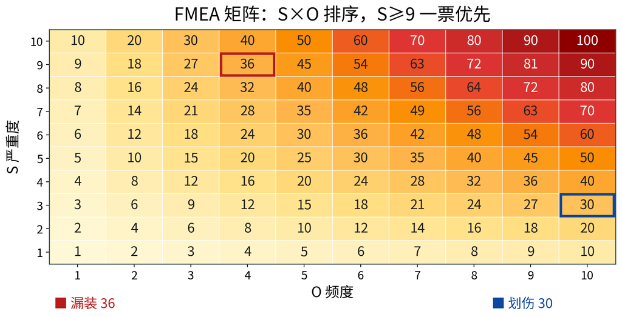

- 两个维度：纵轴严重度 $S$，横轴频度 $O$（可能性）
- 颜色把二维坐标映射为风险等级，用于排序与授权；常见 4×4、5×5
- 图中颜色是 $S\times O$；完整 RPN 还要乘探测度 $D$
- 用法：先定级，再决定立即整改、限期整改或保持监控

## 集对分析：用联系数描述同、异、反

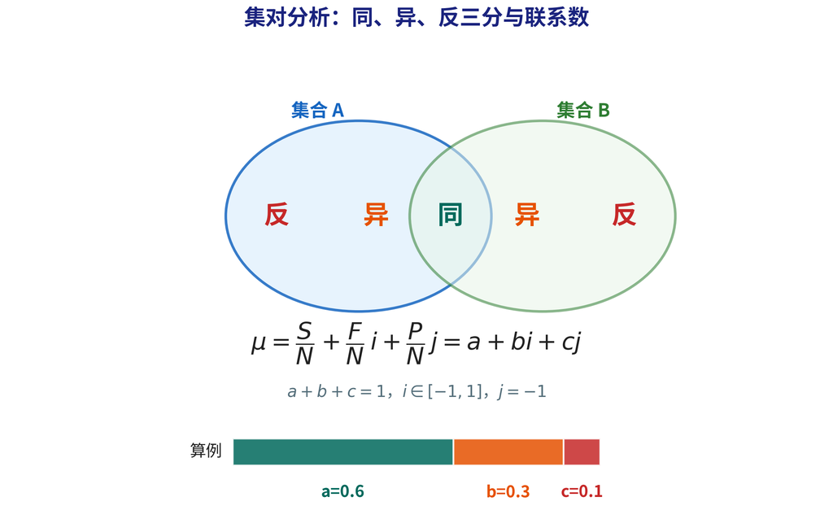

- **是什么**：把两集合特性分三类：共有（同）、非共有非对立（异）、对立（反）
- 联系数 $\mu=S/N+(F/N)i+(P/N)j=a+bi+cj$，且 $a+b+c=1$（$N$ 为特性总数，$S$、$F$、$P$ 分别为同、异、反的特性数）
- **怎么判断**：$a>c$ 同势、$a=c$ 均势、$a<c$ 反势；$a$ 越大越安全

## 效用函数法：把安全偏好折成一个数

> 上一页的联系数把同、异、反合成一个数；这一页看同一谱系里的另一件工具——效用函数，把决策者偏好折成可比较的效用值。
- **是什么**：效用函数 $U(x)$ 把指标取值映射为效用值，反映决策者对该结果的满足程度；值越大越偏好
- 多指标合成：$U=\sum_i w_iu_i$，$w_i$ 为第 $i$ 项指标权重（无量纲，$\sum_i w_i=1$），$u_i$ 为该指标效用值
- 期望效用与风险态度：$E[U]=\sum_i p_iU_i$，$p_i$ 为状态概率；曲线凹为风险厌恶、线性为风险中性、凸为风险偏好，安全决策多取凹曲线
- 算例：方案 A 以 0.5 概率得 100 万元、0.5 概率得 0 元，期望金额 $0.5\times100+0.5\times0=50$ 万元，大于方案 B 的确定 40 万元；取 $U=\sqrt{x}$（$x$ 以万元计）则 $E[U_A]=0.5\times10=5$，$U_B=\sqrt{40}=6.32$，风险厌恶者选 B
- 局限与判据：函数形式由人选定，必须写明依据并做敏感性分析；换一种形式要看排序是否翻转，会翻转就要把形式写进报告

**结论：权重由 AHP 给、等级由模糊法给、偏好排序由效用函数给——三件工具合起来才是一套完整的综合评价。**

## 层次分析法与模糊综合评价

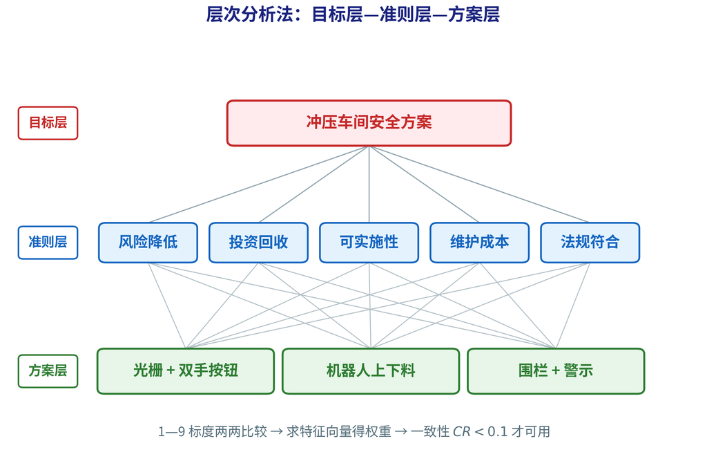

- **AHP**：把复杂问题拆成目标层—准则层—方案层，逐层两两比较
- 判断矩阵用 1～9 标度，权重取 $\lambda_{\max}$ 对应的特征向量（$\lambda_{\max}$ 为最大特征值，$n$ 为矩阵阶数）
- **模糊综合评价**：用隶属度描述“好、较好、一般、差”；步骤为指标集 → 权重 → 矩阵 → 合成 → 定级

## JHA 工作危害分析

> 上一页的综合评价解决“权重怎么定、等级怎么判”；这一页转到作业层面，按任务步骤找危害。
- JHA 以“作业任务”为对象，按步骤识别危害，不针对整个工厂
- 五步：选作业→分步骤→识危害→评风险→定措施
- 适用：检修、动火、有限空间、高处、临时用电等非常规作业
- 输出是一张 JHA 表：步骤、危害、后果、风险、措施、责任人
- 关键：步骤要分到“可观察的动作”，不能只写“检修泵”
- 常见错误：漏掉“能量隔离”和“误启动”这两类危害
- JHA 要覆盖正常、异常、应急三种工况，不能只看平时

| 步骤 | 主要危害 | 可能后果 | 关键控制 |
| --- | --- | --- | --- |
| 停机隔离 | 未彻底隔离、误启动 | 机械伤害、触电 | 上锁挂牌、验电 |
| 泄压排空 | 残余压力、有毒介质 | 喷溅、中毒 | 泄压验证、气体检测 |
| 拆卸密封 | 高温、易燃残留 | 烫伤、火灾 | 冷却、防爆工具 |
| 回装试车 | 防护罩未复位 | 卷入、打击 | 复位确认、点动试车 |

## HAZOP 危险与可操作性分析

- HAZOP 以“工艺参数偏离”为线索，系统查找原因、后果与措施
- 1974 年由英国 ICI 提出，适用于化工、油气等连续流程
- 五个术语：意图、偏离、原因、后果、危险
- 做法：划分节点→定参数→套引导词→分析偏离→形成建议
- 团队作战：工艺、设备、仪表、安全、操作人员共同评审
- 输出 HAZOP 表：节点、引导词、偏离、原因、后果、措施、建议
- 引导词还有“异常/不同于”，表示发生了完全替代原意图的事件

| 引导词 | 含义 | 工艺示例 |
| --- | --- | --- |
| 无/不 | 完全否定意图 | 无流量、无冷却 |
| 多 | 量增加 | 流量过大、温度过高 |
| 少 | 量减少 | 流量不足、压力过低 |
| 伴随 | 伴随其他活动 | 输送 A 时混入 B |
| 部分 | 只达到部分意图 | 只有部分物料通过 |
| 相反 | 逻辑反面 | 逆流、反向反应 |

**结论：HAZOP 的质量取决于节点划分与团队交叉提醒，引导词只是把偏离想全的工具。**

## FMEA 在安全分析中的应用

- FMEA 即故障类型与影响分析，从元件故障向上推影响
- 安全 FMEA 先看严重度 $S$，再看频度 $O$ 与探测度 $D$
- $RPN=S\times O\times D$ 用于排序，但不能替代严重度门槛
- 高危低概率故障可能 RPN 不高，却必须优先控制
- 与 FTA 互补：FMEA 找单点故障，FTA 找组合路径
- 安全 FMEA 常升级为 FMECA，增加危害性/致命度分析
- 局限：难以表达共因失效、顺序相关与系统级组合

| 要素 | 故障类型 | 安全影响 | 控制/探测 |
| --- | --- | --- | --- |
| 制动器 | 制动力不足 | 设备不能停，撞击 | 点检、制动测试 |
| 安全联锁 | 被短接/失效 | 防护门打开仍运转 | 联锁验证、防短接 |
| 急停按钮 | 触点粘连 | 急停无效 | 定期测试、冗余回路 |
| 液压软管 | 破裂 | 高压油喷出、火灾 | 更换周期、护套 |

## 风险评估报告的要素

- 报告要回答四问：评什么、依据什么、怎么评、结论是什么
- 核心要素：范围、依据、系统概况、危险源、方法、结果、措施、结论
- 数据要可追溯：来源、假设、取值理由、不确定性
- 措施要写清责任部门、完成期限、验收标准
- 结论要明确“可接受/不可接受”，不能只写“基本安全”
- 报告要评审、更新，工艺或设备变更后必须重评
- 附件放检查表、照片、计算书与专家意见，保证可复核

| 要素 | 应写清 | 常见缺陷 |
| --- | --- | --- |
| 目的与范围 | 对象、边界、评价类型 | 边界不清、漏接口 |
| 依据 | 法规、标准、导则 | 引用过期标准 |
| 危险源辨识 | 清单、位置、能量形式 | 只写设备、漏管理因素 |
| 评价过程 | 方法、取值、计算 | 只给结果、无过程 |
| 对策措施 | 层级、责任、期限 | 措施空泛、不可验收 |
| 结论 | 可接受性、遗留风险 | 结论含糊、回避签字 |

## 事故树分析：从结果反推原因

> 上一页收在风险评估报告；这一页回答“为什么会出事”——方法是从结果倒推原因。

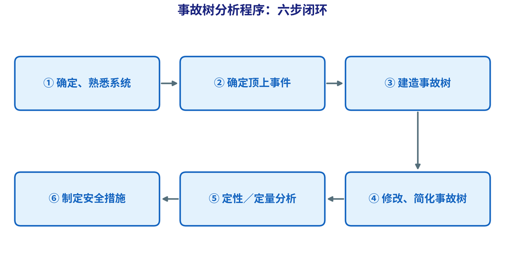

- **是什么**：以事故为顶上事件 $T$（布尔值，1 发生／0 不发生），向下逐层找直接原因，直到基本事件 $x_i$。
- **为什么**：演绎法从结果出发，既找直接原因也找潜在原因。
- 六步：熟悉系统 → 定顶上事件 → 建树 → 化简 → 定性定量 → 措施。
- **怎么判断**：顶上事件选“后果最重、可分解、可预防”的事故，建完请一线评审。

**结论：事故树的价值在建树质量，不在树画得多大。**

## FTA 的用途与局限

- **适合**：后果严重、逻辑关系清楚、可分解为基本事件的系统
- **能回答**：组合原因是什么、哪里最薄弱、顶事件概率多大
- **局限**：建树依赖专家；只能分析选定顶事件；难处理共因失效与时序
- **怎么判断**：顶事件选错，全树白做；共因失效多，割集会低估风险
- 判据：FTA 的价值在建树质量，不在树画得多大

## 事故树的六类事件

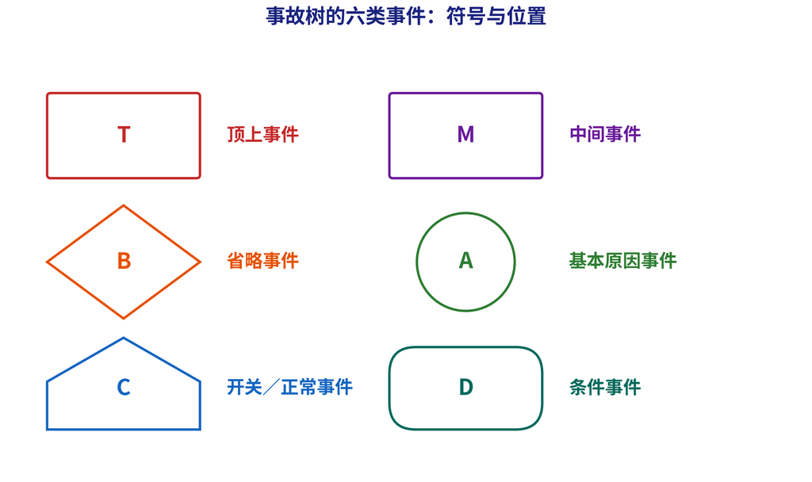

- 结果事件：顶上事件 $T$、中间事件 $M$（矩形）
- 底事件：基本原因事件（圆形）、省略事件（菱形）
- 特殊事件：开关／正常事件（房形）、条件事件（圆角矩形）
- 易错：省略事件不是“不重要”，而是“本次分析不再展开”

## 事故树的逻辑门

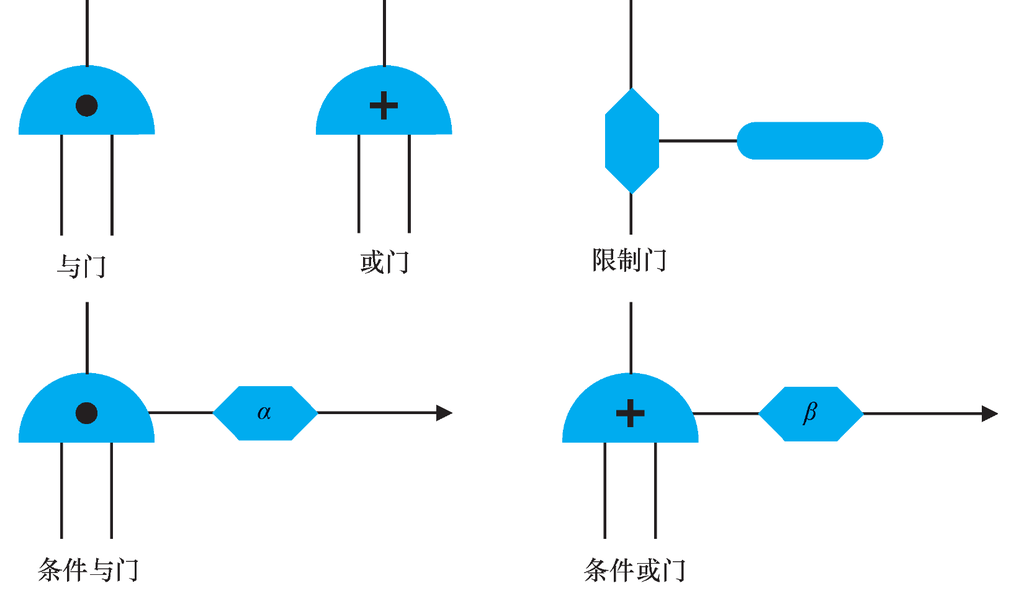

- **与门**：全部输入同时发生才输出，$T=x_1x_2\cdots x_n$（乘）
- **或门**：任一输入发生即输出，$T=x_1+x_2+\cdots+x_n$（加）
- **条件与门**：$T=\alpha\,x_1x_2\cdots x_n$
- **条件或门**：$T=\beta\,(x_1+x_2+\cdots)$
- **限制门**：单输入，$T=x\cdot a$，条件成立才输出

**判门只问一句：缺一路还行不行——行用或门，不行用与门（与门乘、或门加）。**

**易错：或门别画成与门（试卷上或门底边多一个小缺口）；条件门漏乘 α、β；限制门说成“抑制条件不成立”。**

## 事故树建树：顶事件到基本事件

- FTA 用演绎法：从顶事件向下找原因；第一步定系统边界
- 第二步：选顶事件，取后果严重、可分解、可预防的事故
- 第三步：找直接原因，按人、机、料、法、环五类展开
- 第四步：逐层向下，直到不能再分的基本事件
- 第五步：专家评审，检查逻辑门、遗漏与共因失效
- 原则：上一层的“结果”是下一层的“原因”，层级不能乱
- 常见错误：门类型用反、把管理缺陷直接当基本事件、漏正常事件
- 简化：先建完整树，再用布尔代数化简，不要一开始就删事件

**示例**：$T=A_1\cdot A_2$，$A_1$ 为手进入危险区，$A_2$ 为设备未停止

**结论：建树靠演绎逐层追直接原因，化简靠布尔逐项吸收，两步不能合并。**

## 建树实例：油库燃爆事故树

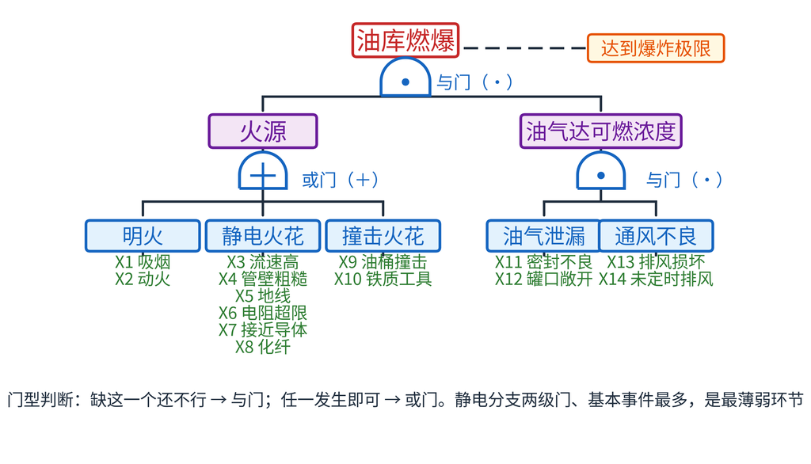

- 判断口诀：“缺这一个还不行”→与门，“任一即可”→或门；**静电分支两级门、事件最多，最薄弱**

## 建树练习：从事故通报到树

- 场景：冲压车间手入模腔致伤，通报给出五条事实
- 第一步定顶事件：**冲压设备伤手**（后果严重、可分解、可预防）
- 第二步找直接原因：手进入危险区 **且** 设备未停止 → 顶层用与门
- 第三步分两支：人因（防护罩缺失、违章伸入、工具不当）／设备（制动失效、联锁失效、误启动）
- **怎么判断**：每一层只写“直接原因”，不能跳级；写完请一线人员评审
- 产出：布尔表达式 + 最小割集 + 两条控制措施

## 建树常见错误：门用反、跳级、漏共因

- 门用反：把“缺一个还行不行”判断错，与门写成或门（最常见）
- 跳级：把管理缺陷直接当基本事件，中间缺了“失效”这一层
- 漏正常事件：设备正常运转、通风正常也是事件，漏了会算错概率
- 漏共因：同一批元件、同一电源、同一套程序导致的失效不能当独立事件
- 一边建树一边删事件：应先建完整树，再用布尔代数化简
- **怎么判断**：拿一张建好的树，问三句——门型对不对、层级乱没乱、共因漏没漏

## 布尔代数化简与等效事故树

- 事故树可以直接写成布尔表达式：与门为乘、或门为加
- 四条依据：幂等 $A+A=A$、$A\cdot A=A$；吸收 $A+AB=A$；分配 $A(B+C)=AB+AC$；德摩根 $\overline{A+B}=\overline{A}\,\overline{B}$
- **算例**：$T=M_1M_2=(x_1+x_2)x_1x_3=x_1x_3+x_1x_2x_3=x_1x_3$
- **怎么判断**：化简后“少掉”的事件是冗余事件，控制它没有意义
- 等效树：保持逻辑结构不变，用最简式重画
- 易错：布尔化简不能像普通代数那样约分，只能用定律

## 布尔化简练习：两个小例子

- 例 1：$T=(x_1+x_2)(x_1+x_3)$，按分配律展开
- 展开式 $x_1x_1+x_1x_3+x_1x_2+x_2x_3$，再用幂等 $x_1x_1=x_1$ 与吸收 $A+AB=A$ 合并
- 结果 $x_1(1+x_3+x_2)+x_2x_3=x_1+x_2x_3$
- 判读：最小割集 $\{x_1\}$、$\{x_2,x_3\}$；$x_1$ 单点即可致事故
- 例 2：$T=x_1x_2+x_1x_3+x_2x_3$（三取二）已是析取标准式，三个二阶割集
- **怎么判断**：化简后逐项检查——每一项是否还能被其他项吸收
- 易错：把 $x_1x_1$ 写成 $x_1^2$；把 $A+AB$ 直接约成 $B$
- 判据：化简到“任何一项都不能再被吸收”为止

## 最小割集：定义与求法

> 上一页讲了布尔化简；这一页回答乘积项是什么——最小割集。
- **割集**：一组基本事件，全部发生时顶上事件必然发生。
- **最小割集**：去掉任一事件就不再是割集的组合（第 $i$ 个记 $K_i$）。
- 求法一：布尔代数化简，每个乘积项就是一个最小割集。
- 求法二：行列法（富塞尔法），从顶上事件逐层替换。
- **怎么判断**：阶数 $r$（割集内事件数，单位“个”）最低的最易发生，优先切断。
- 注意：割集是“同时坏”的一组事件，不是因果链；二阶比三阶更该先治。
- 例见下两页的两种解法，以及第五部分例题 2。

**结论：阶数最低的最小割集最易发生，就是最该先治的薄弱环节。**

## 最小割集求解：布尔化简法

- 例：三取二系统 $T=(x_1+x_2)(x_1+x_3)(x_2+x_3)$
- 先合并前两项：$(x_1+x_2)(x_1+x_3)=x_1+x_2x_3$
- 再乘第三项：$(x_1+x_2x_3)(x_2+x_3)$
- 展开：$x_1x_2+x_1x_3+x_2x_3+x_2x_3=x_1x_2+x_1x_3+x_2x_3$
- 三个最小割集：$\{x_1,x_2\}$、$\{x_1,x_3\}$、$\{x_2,x_3\}$
- 判读：全部是二阶割集，没有单点失效；任意两路同时故障才出事
- 这正是“三取二”冗余的逻辑：允许一路故障，不允许两路
- 注意：展开后要用吸收律去掉被包含的乘积项

## 最小割集求解：行列法与上行法

- 行列法（富塞尔法，1972）：从顶事件开始逐层替换
- 遇或门：把各输入写成不同行；遇与门：把各输入写在同一行
- 直到全为基本事件，再用吸收律去掉包含其他割集的超集
- 上行法：从底向上写各门布尔式，逐层代入，最后展开化简
- 例：$T=M_1+M_2$，$M_1=x_1x_2$，$M_2=x_3(x_4+x_5)$
- 行列展开：$M_1$ 行得 $x_1x_2$；$M_2$ 行得 $x_3x_4$、$x_3x_5$
- 上行代入：$T=x_1x_2+x_3(x_4+x_5)=x_1x_2+x_3x_4+x_3x_5$
- 三个最小割集：$\{x_1,x_2\}$、$\{x_3,x_4\}$、$\{x_3,x_5\}$

| 步骤 | 行列展开 | 得到割集 |
| --- | --- | --- |
| $T=M_1+M_2$ | 两行：$M_1$；$M_2$ | — |
| $M_1=x_1x_2$ | 一行：$x_1x_2$ | $\{x_1,x_2\}$ |
| $M_2=x_3(x_4+x_5)$ | 两行：$x_3x_4$；$x_3x_5$ | $\{x_3,x_4\}$、$\{x_3,x_5\}$ |

## 割集怎么读：阶数、数量与独立性

- **阶数**：割集里基本事件的个数——最少几个同时坏，系统才出事
- **数量**：有多少条不同的失效路径——越多，系统越难守
- 三取二：3 个二阶割集，允许一路故障，不允许两路
- 四取二：$C_4^2=6$ 个二阶割集，冗余度更高
- **怎么判断**：先看有没有一阶割集（单点失效），再看二阶割集的数量
- 判据：冗余必须配“独立性”——同电源、同软件、同批元件会让多路同时失效

## 最小径集与结构重要度

- **径集（成功树）**：原树的对偶——与门换或门、或门换与门、事件取非
- **最小径集**：成功树的最小割集，表示使顶事件**不发生**的最低限度组合
- 二者关系：割集说“怎么出事”，径集说“怎么不出事”
- **结构重要度**：只看事件在树中的位置，不看发生概率
- **怎么判断**：割集越多、阶数越低越危险；径集越多、阶数越低越安全
- 用途：割集定防护重点，径集设计冗余，结构重要度排整改优先级

## 顶事件概率：独立假设与近似

$$P_{\text{与门}}=\prod_{i=1}^{n}q_i,\qquad P_{\text{或门}}=1-\prod_{i=1}^{n}(1-q_i)$$

- 最小割集近似：$P(T)\approx\sum_j\prod_{x_i\in K_j}q_i$——两割集**可能同时发生**时，相加把交叠算重，近似偏大
- 例：$T=x_1x_2+x_3$，$q=(0.1,\ 0.2,\ 0.05)$，$K_1=\{x_1,x_2\}$、$K_2=\{x_3\}$

| 步骤 | 算式 | 结果 |
| --- | --- | --- |
| $P(K_1)$：$x_1$、$x_2$ 同时发生 | $0.1\times0.2$ | $0.02$ |
| $P(K_2)$：$x_3$ 发生 | $0.05$ | $0.05$ |
| 近似：两割集相加 | $0.02+0.05$ | $0.07$ |
| 精确：减交叠 $0.02\times0.05$ | $0.07-0.001$ | $0.069$ |
| 相对误差 | $(0.07-0.069)/0.069$ | $1.45\%$ |

**判据：各割集互斥（不可能同时发生）时相加才精确；不互斥时近似偏大、是上限。独立假设是前提，共因失效会破坏它。**

## 概率重要度 Ig

- 概率重要度：某基本事件发生概率变化时，顶事件概率的敏感度
- 定义：$I_g(i)=\dfrac{\partial P(T)}{\partial q_i}=P(T\mid x_i=1)-P(T\mid x_i=0)$
- 例：$T=x_1x_2+x_1x_3+x_4$，$q=(0.1,0.2,0.3,0.05)$，$P=0.0918$
- 代入两例：$I_g(1)=0.468-0.05=0.418$（$q_1{=}1$ 时 $P{=}0.468$）；$I_g(4)=1-0.044=0.956$
- 排序：$x_4>x_1>x_3>x_2$；$x_4$ 是单事件割集，敏感度最高
- 注意：$I_g$ 是绝对敏感度，不反映事件本身概率的大小

| 事件 | $q_i$ | $I_g(i)$ | 排序 |
| --- | --- | --- | --- |
| $x_1$ | 0.10 | 0.418 | 2 |
| $x_2$ | 0.20 | 0.0665 | 4 |
| $x_3$ | 0.30 | 0.076 | 3 |
| $x_4$ | 0.05 | 0.956 | 1 |

## 临界重要度 Ic

- 临界重要度把“敏感度”和“事件概率”合起来，衡量相对变化
- 定义：$I_c(i)=I_g(i)\dfrac{q_i}{P(T)}$
- 含义：$q_i$ 变化 $1\%$ 时，$P(T)$ 约变化 $I_c(i)\%$（弹性）
- 例：续上页，$P=0.0918$，算得 $I_c=(0.455,0.145,0.248,0.521)$
- 代入：$I_c(1)=0.418\times0.1/0.0918=0.455$、$I_c(4)=0.956\times0.05/0.0918=0.521$
- 排序：$x_4>x_1>x_3>x_2$，与 $I_g$ 排序一致，但差距缩小
- $I_c$ 不要求各项之和为 1，不能当“贡献率”相加
- 用途：在资源有限时，优先降低 $I_c$ 大的事件概率

| 事件 | $q_i$ | $I_g(i)$ | $I_c(i)$ | 排序 |
| --- | --- | --- | --- | --- |
| $x_1$ | 0.10 | 0.418 | 0.455 | 2 |
| $x_2$ | 0.20 | 0.0665 | 0.145 | 4 |
| $x_3$ | 0.30 | 0.076 | 0.248 | 3 |
| $x_4$ | 0.05 | 0.956 | 0.521 | 1 |

## 结构重要度：只看位置

- 结构重要度只看事件在树中的位置，假设各基本事件等可能
- 定义：$I_\phi(i)=\dfrac{1}{2^{n-1}}\sum_X[\phi(1_i,X)-\phi(0_i,X)]$，其中 $n$ 为基本事件个数，$X$ 为其余 $n-1$ 个事件的状态组合，$\phi$ 为结构函数
- 含义：把 $x_i$ 从 0 强行改为 1，在多少种组合下顶事件由不发生变为发生
- 例：续上页树，$n=4$，$2^{n-1}=8$ 种组合枚举：$I_\phi(4)=5/8=0.625$、$I_\phi(1)=3/8=0.375$、$I_\phi(2)=I_\phi(3)=1/8=0.125$
- 排序：$x_4>x_1>x_3=x_2$；$x_4$ 单事件割集，结构上最关键
- 用途：没有故障率数据时，先按结构排整改优先级
- 局限：不考虑概率，可能高估“很少发生但位置关键”的事件
- 与 $I_g$ 可能不一致：结构看位置，概率看实际发生率

## 事故树定量分析算例

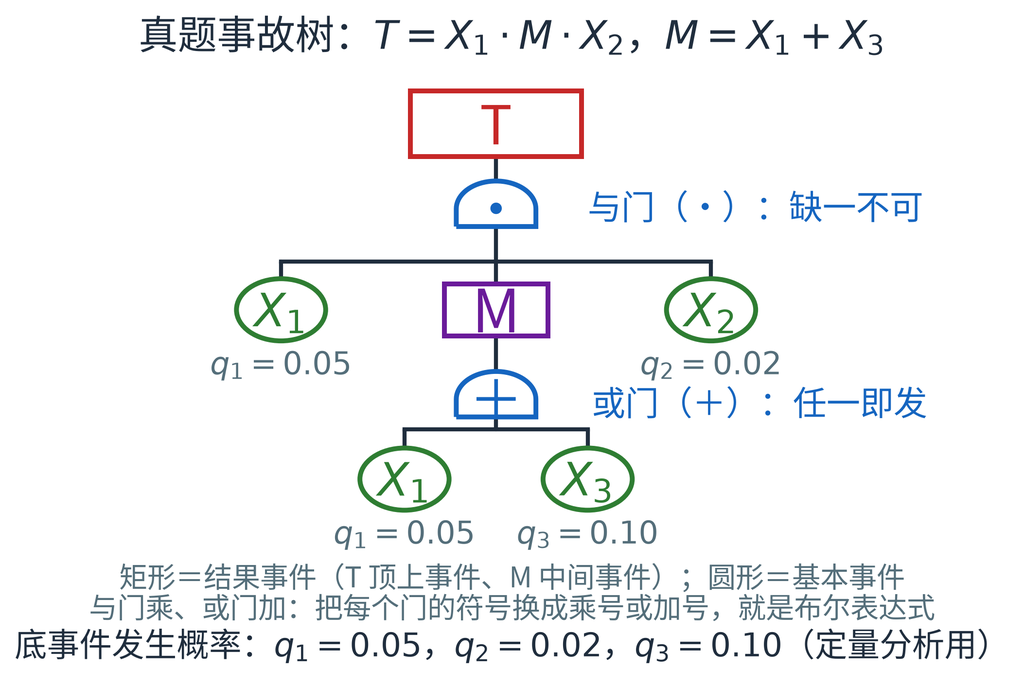

- **化简**：$M=X_1+X_3$ 代入 $T=X_1MX_2=X_1X_2(X_1+X_3)$
  - 展开（分配律）：$=X_1X_1X_2+X_1X_2X_3$
  - 幂等（$X_1X_1=X_1$）：$=X_1X_2+X_1X_2X_3$
  - 吸收（提公因子 $X_1X_2$）：$=X_1X_2(1+X_3)=X_1X_2$ → 最小割集 $\{X_1,X_2\}$
- **X₃ 为何冗余**：顶门本来就要求 $X_1$——$X_1$ 发生，$M$ 必成立；$X_1$ 不发生，$M$ 靠 $X_3$ 也没用；所以 $X_3$ 改变不了 $T$
- 概率与结论：$P(T)=0.05\times0.02=0.001$，$q_3$ 不进结果 → 整改资源给 $X_1$、$X_2$

## ETA 事件树：从原因到后果

> 上一页用事故树把顶事件概率算到 0.001；这一页换个方向，从初始事件推后果。
- ETA 是归纳法：从初始事件出发，按时间顺序推可能的后果
- 例：泵故障停运后，备用泵能否启动、操作员能否干预
- 每个环节只取“成功/失败”两种状态，逐级分叉
- 步骤：定初始事件→辨识后续环节→画树→算路径概率→分级
- 路径概率＝各分支概率连乘；分支完备互斥时，各路径之和为 1
- 与 FTA 相反：FTA 从结果追原因，ETA 从原因推结果
- 用途：找后果链、设计减缓措施、比较不同防护方案

| 路径 | 备用泵 | 操作干预 | 后果 |
| --- | --- | --- | --- |
| 1 | 启动成功 | — | 正常切换，无事故 |
| 2 | 启动失败 | 成功 | 安全停车，短时中断 |
| 3 | 启动失败 | 失败 | 超压/泄漏，事故 |

## FTA 与 ETA 结合：Bow-tie

- Bow-tie 把顶事件放中间：左侧 FTA 找原因，右侧 ETA 推后果
- 左侧屏障叫预防屏障，右侧屏障叫减缓屏障
- 读图：每条原因路径都要有预防屏障，每条后果路径都要有减缓屏障
- 用途：重大危险源、管道、化工装置的风险沟通与屏障管理
- 优点：一张图同时回答“为什么发生”和“发生后会怎样”
- 局限：静态模型，难表达时序、共因失效与动态升级
- 与纯 FTA 比：Bow-tie 的重点不是割集，而是屏障完整性

| 模型 | 方向 | 回答 | 主要输出 |
| --- | --- | --- | --- |
| FTA | 演绎 | 为什么发生 | 原因组合、割集 |
| ETA | 归纳 | 发生后怎样 | 后果路径、概率 |
| Bow-tie | 结合 | 原因—后果全景 | 屏障清单 |

## Bow-tie 案例：油库燃爆的屏障清单

- 左翼（FTA）：明火、静电、撞击三条原因路径
- 右翼（ETA）：燃爆后的池火、毒烟、二次爆炸三条后果路径
- 预防屏障：禁火区管理、静电接地、防撞设施、通风联锁
- 减缓屏障：泄漏检测、紧急切断、消防泡沫、疏散预案
- **怎么判断**：每条原因路径都要有预防屏障，每条后果路径都要有减缓屏障
- 判据：Bow-tie 的重点不是割集，而是**屏障完整性**；缺屏障的路径就是薄弱环节

## 风险控制措施：从消除到 PPE

- 控制措施按可靠性排序：消除＞替代＞工程＞管理＞PPE
- 消除：取消危险工序，或把人工送料改为自动送料
- 替代：水性漆替代溶剂漆，低压替代高压
- 工程控制：防护罩、光栅、联锁、除尘、隔声
- 管理控制：作业许可、上锁挂牌、培训、巡检
- PPE：护目镜、防割手套、安全带，最后一道防线
- 组合原则：工程＋管理＋PPE，不能只发劳保用品

| 层级 | 做法 | 机械车间例子 |
| --- | --- | --- |
| 消除 | 去掉危险源 | 取消手动送料 |
| 替代 | 换低危险工艺 | 水性漆替代溶剂漆 |
| 工程控制 | 隔离/防护/联锁 | 光栅、双手按钮、防护罩 |
| 管理控制 | 制度/培训/许可 | LOTO、动火票、巡检 |
| PPE | 个体防护 | 护目镜、防割手套 |

## 案例：机械伤害事故树

- 教学示例：冲压设备伤手；两条防线必须同时失守才致害
- 树：$T=(x_1+x_2+x_3)(x_4+x_5+x_6)$
- 第一组：导致手进入危险区的因素；第二组：导致设备不能停的因素
- 最小割集：$3\times3=9$ 个，全部为二阶
- 判读：单一失效不足以致害，但“手伸入＋联锁失效”很常见
- 控制重点：联锁与防护罩优先，其次才是培训和手套
- 基本事件要与现场检查项一一对应，树才能落地

| 编号 | 基本事件 | 关键控制 |
| --- | --- | --- |
| $x_1$ | 防护罩缺失/失效 | 防护罩＋联锁 |
| $x_2$ | 违章伸入危险区 | 光栅、双手按钮 |
| $x_3$ | 送料工具不当 | 专用工具、防呆 |
| $x_4$ | 离合器/制动器失效 | 点检、制动测试 |
| $x_5$ | 安全联锁失效 | 联锁验证、防短接 |
| $x_6$ | 误启动/意外启动 | LOTO、启动确认 |

## 案例：高处坠落事故树

- 教学示例：高处坠落；坠落基准面 $2\ \mathrm{m}$ 及以上
- 树：$T=(x_1+x_2+x_3+x_4)(x_5+x_6)$
- 第一组：导致人体失稳/越过临边的因素；第二组：导致保护失效的因素
- 最小割集：$4\times2=8$ 个，全部为二阶
- 判读：任一人因事件＋任一防护失效，即构成一个割集
- 控制重点：护栏、洞口盖板、安全带高挂低用、安全网
- 高坠树可与安全检查表联动，把基本事件变成检查项

| 编号 | 基本事件 | 关键控制 |
| --- | --- | --- |
| $x_1$ | 脚手板未固定/滑移 | 绑扎固定、验收 |
| $x_2$ | 临边/洞口无护栏 | 护栏、盖板、警示 |
| $x_3$ | 违章攀爬/跨越 | 通道、培训、处罚 |
| $x_4$ | 照明不足/平台湿滑 | 照明、防滑、清理 |
| $x_5$ | 安全带未系/挂点失效 | 高挂低用、挂点检查 |
| $x_6$ | 安全网缺失/破损 | 首层网、随层网 |

## 本部分小结

- 风险：可能性×严重度；可接受风险用 ALARP 判断，不追求零风险
- 三类评价：定性（SCL）、半定量（LEC/矩阵）、定量（FTA/ETA）
- LEC：$D=L\times E\times C$；分级边界 $320/160/70/20$
- JHA 跟任务走，SCL 跟设备/场所走，HAZOP 跟工艺偏离走
- FMEA 归纳找单点故障，FTA 演绎找组合路径
- FTA 三步：建树→布尔化简→最小割集；定量算概率与重要度
- 三个重要度：结构看位置，概率看敏感度，临界看弹性
- ETA 从原因推后果，Bow-tie 把 FTA 与 ETA 合成一张图
- 控制措施按消除→替代→工程→管理→PPE 排序
- 会画树、会化简、会算概率、会排措施，是本部分的四项基本功

## 推导留给 AI：风险评估与事故树（汇总）

- LEC 的 $L$、$E$、$C$ 取值带主观性，如何用客观数据（故障率、暴露工时）校准？
- 事故树化简后“消失”的基本事件，在什么情况下仍必须保留在管理清单里？
- 用最小割集近似计算顶事件概率，什么条件下会显著低估或高估？
- 若一个系统的最小割集全是高阶割集（如四阶），是否意味着它安全？还要看什么？

# 第三部分 · 安全责任与智能制造安全

- 《建设工程安全生产管理条例》：五方责任主体各管什么
- **安全事故 vs 安全责任事故**：同是事故，法律后果为何不同
- 两个真实案例：天津港 8·12、泉州欣佳酒店 3·7；智能制造的新安全（人机协作、网络、算法决策）
- 本部分落点：把“责任”落到岗位与制度上
- **承上**：上一部分算清了风险；本部分要回答“出事谁负责”——五方责任、责任事故判定与智能安全的新责任。

## 建设工程安全生产管理条例：五方责任

- **承接**：上一页给出本部分路线；这一页先立法规，把责任分给五方。
- 《建设工程安全生产管理条例》依据《建筑法》《安全生产法》制定，2004 年 2 月 1 日起施行；方针是**安全第一、预防为主**
- **是什么**：建设、勘察、设计、施工、监理五方，各自对施工安全承担法定责任

| 主体 | 核心义务 | 典型失守 |
| --- | --- | --- |
| 建设单位 | 资料真实、不压工期、列安全措施费 | 压工期、压造价 |
| 勘察单位 | 按强制性标准勘察，文件真实准确 | 勘察数据失真 |
| 设计单位 | 按强制性标准设计，注明重点部位 | 未注明施工安全重点 |
| 施工单位 | 专职安全员、专项方案、培训、持证 | 无方案施工、隐患不整改 |
| 监理单位 | 审查方案、发现隐患要求整改或停工 | 只签字不审查 |

- **怎么判断**：看谁掌握决策权——建设单位管钱与工期，设计管源头，施工管现场，监理管把关

## 建设单位与勘察设计单位的责任

- **建设单位：不直接干活，却常是事故的第一推手**
- 提供现场及毗邻区域的管线、气象、水文、相邻建（构）筑物资料，保证**真实、准确、完整**
- 不得提出不符合安全法规和强制性标准的要求，**不得压缩合同约定工期**
- 概算中必须确定**安全作业环境及安全施工措施费**
- 不得明示或暗示施工单位使用不合格的防护用具、机械设备
- **勘察、设计：把安全做进图纸**
- 勘察文件真实准确，作业时保护管线与周边建构筑物
- 设计按强制性标准，**防止因设计不合理导致事故**；涉及施工安全的重点部位须注明
- **怎么判断**：看事故通报里有没有“压缩工期”“未注明”“资料缺失”这三类词

## 施工单位与监理单位的责任

- **施工单位：现场安全的第一责任主体**
- 主要负责人全面负责；项目负责人对项目安全负责
- 按规定配备**专职安全生产管理人员**
- 编制**危大工程**（危险性较大的分部分项工程）专项施工方案，并经审批
- 对从业人员进行安全教育；**特种作业人员持证上岗**
- 提供合格防护用品，对隐患及时整改
- **监理单位：把关而非签字**
- 审查安全技术措施与专项方案；发现隐患要求整改，严重的要求**暂停施工**并报告
- 施工单位拒不整改的，**向主管部门报告**
- **怎么判断**：监理不是施工方的安全员，但“发现隐患不报告”就要担责

## 安全事故 vs 安全责任事故

- **承接**：五方责任分完；这一页回答同样是事故，为什么有的追刑责。
- **安全事故**：从后果看，指生产经营活动中造成人身伤亡或财产损失的事件（含不可抗力、技术局限）
- **安全责任事故**：经调查认定，**因违反安全生产法律法规、未履行安全管理职责**而导致的事故
- **判定核心**：事故是否“本可避免”——存在应尽而未尽的注意义务

| 判定要素 | 安全事故 | 安全责任事故 |
| --- | --- | --- |
| 直接原因 | 可能含不可抗力、未知风险 | 违法建设、违规操作、管理失守 |
| 主体责任 | 无明确过错方 | 有明确责任单位与责任人 |
| 法律后果 | 民事赔偿、工伤保险 | 行政处罚 + 刑事责任 |
| 调查层级 | 按等级常规调查 | 常提级调查、挂牌督办 |

- 一句判据：**“如果按规矩做了，事故还会不会发生？”** 答“不会”，就是责任事故

## 责任事故判定的四个要件

- 法律落点：《刑法》第一百三十四条重大责任事故罪
- 立案追诉：死亡 1 人、重伤 3 人或直接经济损失 100 万元以上
- 四要件缺一不可：没有违规或没有因果，就不能认定
- 因果是争点：辩方常说“即使按规矩做也会发生”
- 非责任事故：不可抗力、技术局限、第三人故意、受害人故意

| 要件 | 证明对象 | 证据来源 | 反例 |
| --- | --- | --- | --- |
| 违规 | 违反安全管理规定或强制性标准 | 规程、方案、交底、验收记录 | 当时标准未作要求 |
| 后果 | 死亡、重伤或重大经济损失 | 尸检、伤情鉴定、损失核定 | 未达追诉标准 |
| 因果 | 违规行为与后果之间有因果链 | 现场勘验、技术鉴定、模拟试验 | 介入因素中断因果 |
| 过错 | 应当预见而疏忽，或轻信可避免 | 岗位职责、培训记录、审批签字 | 不可抗力、不能预见 |

## 案例一：天津港“8·12”特别重大火灾爆炸事故

- **承接**：四个要件立好了；这一页用天津港 8·12 逐条对照。
- **时间地点**：2015 年 8 月 12 日夜，天津市滨海新区天津港，瑞海国际物流有限公司危险品仓库
- **伤亡**：165 人遇难（其中抢险救援人员 110 人：公安现役消防 24、天津港消防 75、公安民警 11）、8 人失踪、798 人受伤
- **直接原因**：集装箱内硝化棉因湿润剂散失局部干燥，高温下分解放热、积热自燃，引燃相邻危险化学品，最终硝酸铵等发生爆炸
- **责任认定**：**特别重大生产安全责任事故**。瑞海公司严重违法违规经营，是事故主体责任单位；天津市交通、港口、海关、安监、规划国土等部门违法违规许可、日常监管严重缺失
- **追责后果**：49 名企业人员和行政监察对象被立案侦查并采取刑事强制措施；另对 123 名责任人员提出处理意见，建议对 74 人给予党纪政纪处分；瑞海公司证照被吊销、罚款，主要负责人终身不得担任本行业生产经营单位负责人
- **教训**：非法建设危险货物堆场、多次违规变更经营资质、安全评价与环评中介弄虚作假

## 案例二：泉州欣佳酒店“3·7”坍塌事故

- **时间地点**：2020 年 3 月 7 日 19 时 14 分，福建省泉州市鲤城区，欣佳酒店所在建筑物
- **伤亡与损失**：29 人死亡、42 人受伤，直接经济损失 5794 万元
- **特殊背景**：事发时该酒店为鲤城区新冠肺炎疫情防控外来人员集中隔离健康观察点
- **直接原因**：责任单位将原四层建筑违法增加夹层改建成七层，达到极限承载能力；事发前对底层支承钢柱违规加固焊接，引发钢柱失稳破坏，导致整体坍塌
- **责任认定**：**重大生产安全责任事故**（国务院提级调查）。企业违法违规建设施工、弄虚作假骗取行政许可；工程质量检测、建筑设计、消防检测等中介机构出具虚假报告；住建、规划、城管、消防等部门监管失职失察
- **追责后果**：23 名涉嫌犯罪的责任人被采取刑事强制措施；公职人员被追责问责

## 责任追究：三类责任者

- **承接**：责任认定之后要分到人头上；这一页把责任者分成三类。
- 依据《中国共产党纪律处分条例》，违纪行为有关责任人员分三类

| 类别 | 定义 | 关键 |
| --- | --- | --- |
| 直接责任者 | 不履行或不正确履行职责，对损失起决定性作用 | 是否违规 |
| 主要领导责任者 | 对直接主管的工作不履行或不正确履行职责 | 落实到位 |
| 重要领导责任者 | 对应管或参与决定的工作不履行或不正确履行职责 | 贯彻到位 |

- 企业内对应：岗位操作者 → 班组长／车间主任 → 分管副总／主要负责人
- 追责原则：**权责一致**——有多大的决策权，就担多大的责任
- **怎么判断**：看签字、审批、验收记录；签字即担责，不是流程形式

## 主要负责人与安全管理人员的法定职责

- 第一责任人：主要负责人全面负责，不只是分管安全的那位
- 安全员能制止违章、能报告，全面停产仍由主要负责人决定
- 免责的前提是履职留痕：会议纪要、签批、检查与整改闭环
- 2021 年修正的两个关键词：**全员安全生产责任制**、**双重预防机制**（安全风险分级管控＋隐患排查治理）
- 事故调查先问：这五类职责里，哪一项断了

| 职责维度 | 主要负责人 | 安全生产管理人员 |
| --- | --- | --- |
| 组织制度 | 建立健全全员安全生产责任制 | 参与拟订制度、规程与预案 |
| 教育培训 | 组织制定并实施培训计划 | 组织或参与培训，如实记录 |
| 投入条件 | 保证安全生产投入有效实施 | 提出改进建议，督促整改 |
| 风险隐患 | 建立双重预防机制，督促消除隐患 | 辨识评估危险源，排查隐患 |
| 应急报告 | 组织预案与演练，及时如实报告 | 组织或参与应急演练 |

## 安全生产费用：提取、使用与算例

- 依据财资〔2022〕136 号，机械制造按上年度营业收入**超额累退**（分段按档计提）提取
- 用途：安全设施、信息系统与网络安全、防护用品、培训奖励、安全生产责任保险（安责险）等
- 管理四原则：筹措有章、支出有据、管理有序、监督有效
- 建设工程按造价提取：矿山 3.5%、房建 3%、市政 1.5%
- 安全费用是预防性投入，省下的会在事故损失里加倍偿还

| 档 | 营业收入区间 | 提取比例 | 2 亿元时计提 |
| --- | --- | --- | --- |
| ① | 1000 万元以内 | 2.35% | 23.5 万元 |
| ② | 1000 万～1 亿元 | 1.25% | 112.5 万元 |
| ③ | 1 亿～10 亿元 | 0.25% | 25.0 万元 |
| 合计 | — | — | 161.0 万元 |

## 相关方管理：承包商与供应商

- **承接**：钱到位了，还要管住外来的施工队与供应商。
- 法条：不得发包或出租给不具备安全生产条件或相应资质的单位或个人
- 同一区域两个以上单位作业，须签安全协议并指定专职安全员协调
- 核心判据：发包不等于转移责任，业主仍负统一协调管理之责
- 三个失效：以包代管、以罚代管、协议签了不交底
- 智能工厂新增相关方：机器人集成商、软件商、云服务商

| 环节 | 承包商管理 | 供应商管理 |
| --- | --- | --- |
| 准入 | 资质、业绩、人员证书、安全协议 | 生产许可、认证、随机安全文件 |
| 交底 | 风险告知、作业许可、监护人 | 安装调试交底、操作维护培训 |
| 过程 | 旁站监护、检查、变更审批 | 危化品“一书一签”、备件质量 |
| 验收 | 工完料尽场地清、资料归档 | 安全功能验收、遗留问题闭环 |
| 评价 | 绩效评分、黑名单、续用 | 合格供方名录、退出机制 |

## 智能制造安全：新风险从哪里来

- 传统风险仍在：机械伤害、电气、起重、危化品、高处坠落
- 新增四类风险：

| 新风险 | 来源 | 后果 |
| --- | --- | --- |
| 人机协作 | 协作机器人与人在同一空间 | 撞击、挤压；安全距离失效 |
| 网络与数据 | 设备联网、远程运维、云平台 | 非法指令、勒索攻击致停线或失控 |
| 算法决策 | 视觉检测、预测维护、AI 排产 | 漏检、误判、模型漂移 |
| 信息与隐私 | 人员定位、行为识别、视频 | 隐私被侵犯、数据泄露 |

- **怎么判断**：新风险的特点是看不见、跨系统、传播快；传统检查表查不到，要靠监测与评估
- 安全工程的角色：从“事后调查”变为贯穿全生命周期的守护者（设计—生产—运维—废弃）
- 顶层设计顺序：**设备 → 环境 → 人**

## 安全树评测：从 1 : 29 : 300 到一分定音

> 上一页把智能制造的新风险分成四类；这一页回到静态侧，看安全树怎样把能量、危险源与事故组织成一棵可算的树。
- **是什么**：按能量原理与层次分析法，对全过程分区域、对中间过程分块、对最低层次分类建树，实现安全要素全覆盖与正则化
- 评测四步：① 按海因里希法则 1 : 29 : 300、以轻伤为基准定权重 → ② 建树并用布尔代数化简 → ③ 用六类分析做正则化、修正权重 → ④ 合成一个综合分值，即“一分定音”
- 六类分析：客观与专家评价、事故树分析、区域安全分析、特定风险分析、能量跟踪与屏蔽分析、环境因素分析
- 基准权重算例：以轻伤为 1，重伤 $1/29=0.034$、无伤害 $300/29=10.34$；三类归一化后为 $1/330=0.30\%$、$29/330=8.79\%$、$300/330=90.91\%$
- 判据与局限：树要化简到基本事件层、权重不能全由专家拍、一分定音要能复算；静态权重不随工况变，必须接动态评测与实时修正

**结论：安全树把“能量—危险源—事故”的因果固定成可算的结构；静态定权重、动态评风险、实时做预警。**

## 安全评价的八个断点与七条改造线

> 上一页的安全树给出静态评测的骨架；这一页看这套方法在实践中还不够的八处，以及改造的七条线。
- 断点（一）：国内——自研的集对分析等国外不用；静态——静态评估多，缺监控条件下的动态演化；主观——权重靠经验；粗糙——安全要素未全覆盖、树没化简
- 断点（二）：独立——缺人机料法环的交叉影响；死板——不能随公司阶段性目标调整；人——缺人的核心作用的量化；措施——评价结果没接进“四不放过”的整改闭环
- 改造（一）：顶层设计——分模块完善，设备→环境→人；阶段实施——由粗到细，工亡→工伤→质量→效率；目标导向——权重随公司目标动态调整；建立模型——集对分析加深度学习
- 改造（二）：动态演化——用马尔可夫链描述状态转移；耦合权重——以人为核心，机料法环交叉；决策分析——建知识图谱，给量化指标与建议
- 三条主线：从静态到动态、从主观到数据、从单点到耦合
- 判据：改造要落成可复算的模型，不能停在“加强管理”“提高意识”

**结论：断点要靠动态数据与 AI 补，静态权重只是起点——后面的智能安全就是改造后的样子。**

## 智能安全：安全网络与 AI 实时分析

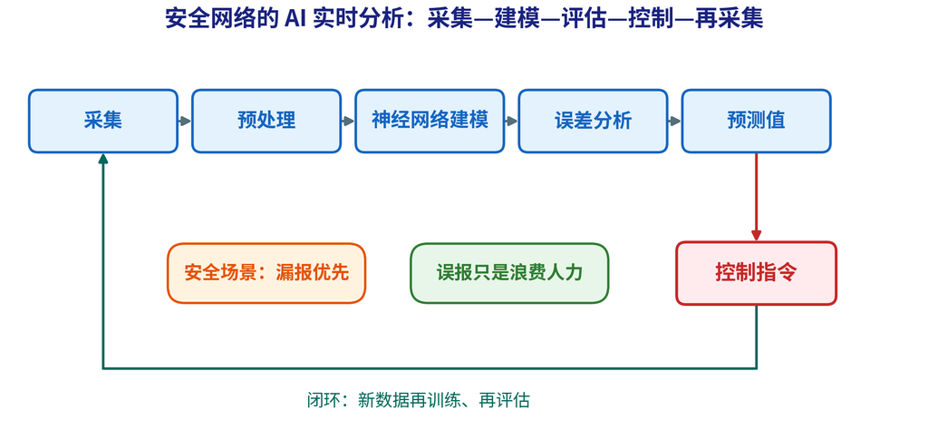

- 三阶段：静态（分类整理、AHP 层次分析法与安全树）→ 动态（全生命周期测评、FTA 故障树分析／FMEA 失效模式与影响分析／PRA 概率风险评估）→ 实时（安全网络 AI）
- **怎么判断**：安全 AI 的第一指标是**召回率**（漏报率），不是准确率——漏一次可能就是一条命
- 跳步警告：没有静态台账与动态测评，直接上 AI 等于在沙地上盖楼

## 人员行为特征挖掘：防呆而非追责

- **承接**：AI 盯设备与工艺，也能盯人的行为；这一页讲行为特征。
- 五个要素“人机料法环”中，**人处于核心地位**；违章操作是事故主要因素
- **重新定义违章**：不是个人品德问题，而是流程、排班、界面设计的问题
- 做法：对违章人员的动态网络做聚类，提取行为特征，形成新的管理准则或**防呆设计**
- 实例：三班制工厂周二夜班事故最多——周二是换班第三天，生物钟处于低点
- 对策不是“周二夜班多罚”，而是调整轮班周期、加强交接、关键工序自动化
- 判据：安全管理的最高境界不是“抓违章”，而是**让违章在物理上不可能**

## 智能安全监测：传感器、视频与气体检测

- **承接**：行为特征要落到数据上；这一页讲现场监测测什么、报多少。
- 气体报警：可燃 25%／50%LEL（爆炸下限），有毒 100%／200%OEL（职业接触限值）
- 四类原理：催化燃烧、电化学、红外、PID（光离子化）
- 四个指标：覆盖率、响应时间、误报率、漏报率
- 安全场景以漏报为主要矛盾，误报只是浪费人力
- 失效安全：断线、超量程、标定过期都应报警

| 手段 | 监测对象 | 关键判据 | 典型失效 |
| --- | --- | --- | --- |
| 参数传感 | 温度、振动、电流、位移 | 趋势与阈值 | 漂移、断线 |
| 视频识别 | 安全帽、闯入、跌倒、烟火 | 召回率优先 | 遮挡、逆光、油污 |
| 气体检测 | 可燃气体、有毒气体、缺氧 | 25%LEL；缺氧 19.5% | 标定过期、位置不当 |
| 人员定位 | 区域人数、滞留、越界 | 电子围栏 | 标签漏读、遮挡 |

## 工业互联网+安全生产：预警与追溯

- **承接**：单点监测要连成平台；这一页看“工业互联网+安全生产”。
- 政策：工信部、应急管理部《“工业互联网+安全生产”行动计划》；五个能力：快速感知、实时监测、超前预警、联动处置、系统评估
- 三个转变：静态→动态、事后→事前、单点→全局
- 预警分级：阈值报警、趋势预警、模型预警，逐级提前
- 四层架构：设备—边缘—平台—应用，数据统一编码；追溯靠“一患一档、操作留痕”
- 关键：报警必须闭环处置，“报警不处置”比“不报警”更危险

## 数字孪生与安全仿真：先试错，再投产

- 数字孪生五维：物理实体、虚拟实体、服务、数据、连接
- 价值：把事故后调查变成事故前试错，虚拟调试与演练不伤人
- 局限：模型误差、边界假设、人的行为难建模

| 仿真类型 | 回答的问题 | 关键输入 |
| --- | --- | --- |
| 泄漏扩散 | 气体往哪走、多久到人 | 泄漏源、通风、地形 |
| 火灾爆炸 | 影响范围与后果 | 物料、点火源、结构 |
| 机器人干涉 | 安全距离够不够 | 运动轨迹、速度、布局 |
| 人员疏散 | 多久能撤完 | 人数、出口、路径 |

公式

$$t_e = t_r + \frac{L}{v} + t_q \qquad (t_e,t_r,t_q:\mathrm{s};\ L:\mathrm{m};\ v:\mathrm{m/s})$$

- 疏散时间 $t_e$ 拆三段：反应 $t_r$、行走 $L/v$、排队 $t_q$

## 协作机器人：ISO 10218 与 TS 15066

- **承接**：仿真可以验证布局；这一页讲人机同场的标准与硬约束。
- 标准：ISO 10218-1 管制造商，-2 管集成与机器人单元
- ISO/TS 15066 已并入 ISO 10218，四种协作方式仍是骨架
- 协作机器人不是天然安全，仍须按 ISO 12100 做风险评估
- 保护距离 $S = K T + C$：$S$ 保护距离（mm）、$K$ 接近速度（mm/s）、$T$ 响应时间（s）、$C$ 附加距离（mm）
- 末端执行器与工件也是危险源；功能安全按 ISO 13849 或 IEC 62061

| 协作方式 | 原理 | 适用场景 |
| --- | --- | --- |
| 监控停止 | 人进入即停，离开后恢复 | 上下料、检验 |
| 手动引导 | 人握持工具引导机器人 | 示教、精密装配 |
| 速度分离 | 按距离降速并保持间距 | 共享工作空间 |
| 功率与力限 | 限制接触力与接触压力 | 直接协作装配 |

## AI 安全风险：算法、传感器与网络

- **承接**：机器人之外，AI 本身也有风险；这一页看三类失效。
- AI 失效不报错，只给错答案：模型不会说“我不知道”
- 安全场景第一指标是漏报率；误报太多会被静音
- 防护四件套：异构冗余、输入监控、版本受控、降级回退
- 底线：AI 不进安全功能回路，联锁由安全仪表系统（SIS）或硬接线完成
- 法条：禁止关闭、破坏监控报警设备或篡改相关数据

| 风险 | 触发场景 | 后果 | 防线 |
| --- | --- | --- | --- |
| 算法失误 | 分布漂移、标注偏差 | 漏检、误判 | 异构冗余、在线监控 |
| 传感器故障 | 镜头污染、遮挡、漂移 | 输入失真 | 自检、标定、失效报警 |
| 网络攻击 | 勒索、伪造数据、越权 | 停线、失控 | 分区隔离、白名单、审计 |
| 责任分散 | 多方参与、无人认账 | 责任真空 | 合同约定、签字留痕 |

## 安全仪表系统与 SIL 功能安全

- SIS 三件套：传感器、逻辑控制器、最终执行元件
- 标准：IEC 61508 通用、IEC 61511 过程工业、ISO 13849 机械（PL 性能等级）
- SIL 是安全功能的完整性等级，不是某台仪表的等级
- 关键参数：PFDavg（平均要求时失效概率，无量纲）、硬件故障裕度、安全失效分数、共因失效
- 安全生命周期：分析→要求→设计→验证→运维→变更
- 误区：买了高 SIL 仪表，不等于实现了高 SIL 功能

| SIL | PFDavg（低要求模式） | 风险降低因子 |
| --- | --- | --- |
| SIL 1 | $10^{-2}\sim10^{-1}$ | 10～100 |
| SIL 2 | $10^{-3}\sim10^{-2}$ | 100～1000 |
| SIL 3 | $10^{-4}\sim10^{-3}$ | 1000～10000 |
| SIL 4 | $10^{-5}\sim10^{-4}$ | 10000～100000 |

## 案例：预警成功，泄漏未成灾

- **承接**：技术防线讲完；这一页看一次成功的预警链条。
- 情景：某涂装厂调漆间，可燃气体探测器与视频联动（示例数据）
- 结果：15 分钟处置完毕，未发生燃爆、无伤亡（示例）
- 价值：预警不在“报了”，而在“报了有人管、管了有闭环”
- 任一环断：未标定、被静音、未联动、无人敢停机

| 时刻 | 系统动作 | 人的动作 |
| --- | --- | --- |
| T+0 | 26%LEL 报警并推送 | 值班员接警 |
| T+1 min | 联动排风、视频弹窗 | 远程确认泄漏 |
| T+5 min | 持续监测、趋势曲线 | 停机、断电、撤人 |
| T+15 min | 浓度回落至 5%LEL | 现场复查、解除 |

## 案例：AI 视觉漏检，联锁为何失守

- **承接**：上一个是成功的链条；这一个看同样的技术为何失守。
- 情景：AI 视觉兼作冲压启动联锁，为提节拍改成“报警不停机”（示例）
- 失效链：油污→对比度降→置信度 0.92→0.61→仍判“无人”
- 根因：非安全级 AI 进安全回路；旁路无审批；无漂移监控
- 法条：禁止关闭、破坏监控报警设备，禁止篡改数据

| 失效环节 | 事实 | 本可拦截的措施 |
| --- | --- | --- |
| 镜头污染 | 无清洁与自检 | 污染检测、定时擦拭 |
| 模型输出 | 置信度低仍放行 | 低置信度转人工或停机 |
| 联锁旁路 | 为节拍长期旁路 | 挂牌上锁、审批、时限 |
| 变更管理 | 模型升级未评估 | 变更评审与回归测试 |

- **结论：把非安全级 AI 放进安全回路、旁路无人管，才是失守根因。**

## 谁为安全负责：法律、职业与道德

- **承接**：技术防线之外，还有一层是人的责任；这一页分三种视角。
- 三种责任视角：法律看违法，职业看签字，道德看能否预见与阻止
- 责任分散四手法：界限模糊、细节下压、功劳上移、拉多人决策
- 工程师不因“领导决定”免责：公众安全、健康、福祉优先
- 三个自问：能否预见？能否阻止？是否留下记录？
- 制度：安全否决权、匿名报告、无责备文化

| 责任类型 | 问的问题 | 落到什么证据 |
| --- | --- | --- |
| 法律责任 | 违反了哪条规定 | 法规、许可、处罚决定 |
| 职业责任 | 谁签字、谁胜任 | 图纸、方案、验收单 |
| 道德责任 | 谁本可预见并阻止 | 邮件、会议记录、报告 |

- **结论：责任分散的四种手法要能识别，三个自问要能回答。**

## 责任的三层：行政、民事、刑事

- **承接**：上一页按法律、职业、道德分责任；这一页按性质分。
- 行政责任：罚款、降资质、吊销证照、行政拘留——由监管部门作出
- 民事责任：赔偿医疗、误工、伤残、死亡赔偿金——由受害方起诉
- 刑事责任：重大责任事故罪、污染环境罪等——由司法机关追究
- **怎么判断**：看行为违反的是哪类规范——法规→行政，合同／侵权→民事，刑法→刑事
- 三种责任可以并存：一起事故可能同时罚款、赔偿、判刑
- 《建设工程安全生产管理条例》五方失职处罚档：建设单位 20 万～50 万元；勘察设计、监理各 10 万～30 万元；施工停业整顿、吊证；其他相关方按合同价款 1～3 倍
- 判据：企业常只算民事赔偿，忽略行政与刑事的连锁后果

## 安全否决权与举报：工程师的最后一道防线

- **承接**：责任分完，个人的最后一道防线是行使否决权与举报。
- **是什么**：工程师发现重大隐患时，有权拒绝签字、要求停工、向上报告
- **为什么**：责任不能只落在“最后按按钮的人”；掌握数据的人沉默，等于默许
- 制度三件套：安全否决权、匿名报告渠道、无责备文化
- **怎么判断**：看三件事——否决有没有记录、报告有没有回应、举报人有没有被报复
- 现场做法：先书面留痕（邮件、会议纪要），再走内部渠道，必要时向监管部门举报
- 判据：一个组织是否真重视安全，看坏消息能不能传到一把手

## 本部分小结：责任、程序与技术防线

- **承接**：第三部分到这里收口：把责任、程序、技术串成四句。
- 一条判据：如果按规矩做了，事故还会不会发生？
- 一个顺序：消除→替代→工程控制→管理控制→个体防护
- 一个底线：AI 不进安全功能回路，联锁独立、可验证、旁路受控
- 一句：安全不是某个岗位的职责，而是每个决策点的否决权

| 防线 | 关键手段 | 判据 |
| --- | --- | --- |
| 责任 | 五方责任与全员责任制 | 是否有清单与签字 |
| 程序 | 报告、调查、证据链 | 三条线是否闭合 |
| 技术 | 监测、平台、SIS | 漏报率与独立性 |
| 投入 | 安全生产费用 | 是否足额、专用 |

## 推导留给 AI：安全责任与智能安全（汇总）

- **承接**：小结之后，留四个问题延伸到课后与后面的讲次。
- “如果按规矩做了事故就不会发生”这一判据，在新技术（无先例）场景下还适用吗？
- 建设单位压缩工期导致事故，如何证明“压缩工期”与事故之间的因果关系？
- 安全 AI 的漏报与误报，哪个代价更高？如何设定告警阈值？
- 人员行为数据用于安全管理，边界在哪里？员工有没有“不被算法画像”的权利？
- **结论：四个问题都指向把责任、因果与边界说清楚的能力。**

# 第四部分 · 环保工程

- 工程与环境：环境友好型工程、环保运动与法规
- 三废治理：废气、废水、固废的技术路线
- 清洁生产与绿色制造；碳达峰碳中和
- 环境成本由谁承担、环评与公众知情；把“环保”从口号变成工艺与账本
- **承上**：上一部分判清了安全责任；本部分要回答“环境代价怎么管”——环评、三废治理与双碳。

## 工程与环境：环境友好型工程

- **环境**：影响人类生存和发展的各种天然的和经过人工改造的自然因素总体
- **环境污染**：人类直接或间接向环境排放超过其**自净能力**的物质或能量，使环境质量降低
- 工程与环境的三层关系：

| 层次 | 表现 | 工程应对 |
| --- | --- | --- |
| 索取 | 资源与能源消耗 | 提高效率、循环利用 |
| 排放 | 废气、废水、固废、噪声 | 末端治理、达标排放 |
| 改变 | 土地利用、生态格局、气候 | 环评、生态修复、低碳设计 |

- **环境友好型工程**：既满足功能与成本，又把全生命周期环境负荷降到最低
- **怎么判断**：环境约束越早进入设计，代价越低——末端治理最贵，源头设计最便宜

## 环保运动的起点：寂静的春天与地球日

- 1962 年 9 月 27 日，蕾切尔·卡逊《寂静的春天》出版：DDT 等农药沿食物链富集，鸟类与人类受害
- 1970 年 4 月 22 日首个**地球日**（约两千万人参与）；同年美国通过**《清洁空气法》**——环保从道德呼吁变成法律
- 1990 年《污染预防法》：从“治理污染”转向“预防污染”

[figure not shown]

*《寂静的春天》与蕾切尔·卡逊*

## 环保法规与国际进程

- 我国体系：宪法（第 26 条）→《环境保护法》→ 单行法（大气、水、固废、噪声、环评、清洁生产）→ 行政法规 → 部门规章 → 环境标准
- 关键制度：**环境影响评价**、**“三同时”**、排污许可、总量控制、排污收费／环境保护税
- 刑事责任：污染环境罪（刑法第 338 条）；2013 年“两高”司法解释降低入刑门槛，界定“严重污染环境”的 14 项标准

| 时间 | 事件 | 意义 |
| --- | --- | --- |
| 1962 | 《寂静的春天》出版 | 现代环保运动起点 |
| 1970 | 首个地球日、《清洁空气法》 | 环保进入法律 |
| 1972 | 联合国人类环境会议（斯德哥尔摩） | 国际环境治理开端，设世界环境日 |
| 1992 | 联合国环境与发展大会（里约） | 可持续发展成为共识，《气候变化框架公约》 |
| 1997 | 《京都议定书》 | 发达国家量化减排 |
| 2015 | 巴黎气候变化大会 | 全球升温控制目标 |
| 2020 | 中国提出“双碳”目标 | 2030 年前碳达峰、2060 年前碳中和 |

**结论：我国环境法已形成宪法—法律—法规—规章—标准的层级体系，国际进程则从末端治理走向预防与低碳。**

## 环评流程：从报告书到验收

- 对象：规划与建设项目——分析、预测、评估其实施后的环境影响并提出对策；分类管理（报告书／报告表／登记表）
- 流程：编制 → 审批 → 开工 → 施工监管 → 自主验收 → 排污许可
- “三同时”：防治设施与主体工程同时设计、施工、投产
- 2017 年起，竣工环保验收由企业自主完成
- 排污许可：环评批复后申领，按证排污、持证监管
- 规划环评：园区、流域、矿区，从源头定产业与布局
- 区域限批：环境质量不达标或环评违法的地区被限批
- 碳评：部分行业试点把碳排放纳入环评
- 公众参与是法定环节：公众知情与意见表达是环境决策合法性的来源
- 判据：规划环评定布局，项目环评定工艺，验收看落实；四类违法——编制造假、审批越权、未验先投、监测数据造假

## 环境标准与排放限值：合规的尺子

- 体系：国家标准（GB）→ 地方标准（通常更严）→ 行业标准
- 两把尺：**排放标准**管“排多少”，**环境质量标准**管“环境里允许多少”，不能混用
- 关键限值：COD、氨氮、SO₂、NOx、颗粒物、VOCs 各有行业与区域差别
- **怎么判断**：先看管的是排放口还是环境介质，再看行业、区域、时段（昼／夜）
- 特别排放限值：重点地区执行更严的限值，环评批复还可能加严
- 判据：达标是底线，不是安全线；总量控制与无组织排放同样要管

## 排污许可与证后监管

- **是什么**：一证式管理，把排污口、污染物、浓度、总量、监测要求写进许可证
- 流程：环评批复 → 申请与核发 → 按证排污 → 自行监测 → 台账与执行报告 → 监管执法
- **为什么**：环评管“能不能建”，排污许可管“能排多少”，验收管“建得对不对”
- **怎么判断**：看三本账——许可证载明事项、在线监测数据、执行报告是否一致
- 无证排污、超许可排污、篡改数据，都是违法行为
- 判据：证、账、数三者对不上，就是证后监管的漏洞

## 世界八大公害：八个现场与一条共同逻辑

- 马斯河谷（比利时，1930）：SO₂ 与氟化物、粉尘在逆温雾中积聚，数千人发病
- 多诺拉（美国，1948）：锌冶炼烟气困于河谷，全镇约四成居民患病
- 伦敦（英国，1952）：燃煤烟尘与 SO₂ 五天不散，死亡人数激增数千
- 洛杉矶（美国，1943 起）：汽车尾气经阳光照射，生成光化学烟雾
- 水俣病（日本，1956）：甲基汞经鱼贝富集，损伤中枢神经
- 痛痛病（日本富山，1910s 起）：镉污染稻米，肾损害与骨软化
- 四日市哮喘（日本，1961）：石化与燃煤排放，呼吸系统疾病成片发生
- 米糠油（日本，1968）：多氯联苯混入食用油，造成大规模中毒
- 共同结构：可测的污染物、可追的暴露、可鉴的损害、可诉的责任
- 共同后果：公众运动、环境立法、损害赔偿诉讼相继出现
- 结论：环境问题从“天灾”变成可取证、可追责的技术—法律问题

## 中国环境形势：结构未变，拐点已现

- 结构未变：重化工为主的产业结构、以煤为主的能源结构、以公路为主的运输结构
- 2023 年：339 个城市 PM2.5 平均 30 μg/m³，优良天数比例 85.5%
- 地表水Ⅰ—Ⅲ类断面 89.4%，劣Ⅴ类 0.7%；受污染耕地安全利用率 91% 以上
- 但臭氧污染、季节性重污染、排放总量仍处高位
- 法制：2014 年修订《环境保护法》，2015 年施行，被称为“史上最严”
- 硬手段：按日计罚、查封扣押、行政拘留、环境公益诉讼
- 制度：生态保护红线（陆域约 30%）、排污许可、环保税、中央环保督察
- 战役：蓝天、碧水、净土三大保卫战
- 战略：2030 年前碳达峰、2060 年前碳中和

**结论：结构未变、拐点已现——治理正从末端达标转向质量改善与双碳协同。**

## 大气污染：四类污染物与治理逻辑

- 颗粒物：TSP、PM10、PM2.5（细颗粒物）；来源为燃烧、工业、扬尘、机动车
- PM2.5 可入肺泡并进入血液，是健康危害最大的污染物
- SO₂：燃煤与冶炼排放，刺激呼吸道，是酸雨前体
- NOx：高温燃烧的热力型与燃料型，生成硝酸盐气溶胶与臭氧
- VOCs：涂装、印刷、石化、溶剂使用，是臭氧与二次有机气溶胶前体
- 二次生成：NOx 与 VOCs 在阳光下生成 O₃ 与 PAN
- 酸沉降：SO₂、NOx 转化为硫酸与硝酸，随降水落地
- 两类典型烟雾：还原型（伦敦，SO₂ + 颗粒物）、氧化型（洛杉矶，NOx + VOCs + O₃）
- 同根同源：化石燃料燃烧同时产生 CO₂ 与污染物
- 治理逻辑：源头替代、过程收集、末端净化，按污染物与浓度选

## 除尘：旋风、布袋、静电怎么选

- 选型先看四件事：粒径分布、烟气温度、湿度与黏性、风量与含尘浓度

| 技术 | 适用粒径 | 效率 | 特点与局限 |
| --- | --- | --- | --- |
| 旋风除尘 | $>5$–$10\ \mu\mathrm{m}$ | 70%–90% | 结构简单、耐高温；细颗粒效率低 |
| 布袋除尘 | $>0.1\ \mu\mathrm{m}$ | 99% 以上 | 出口可低于 10 mg/m³；怕结露糊袋 |
| 静电除尘 | $>0.1\ \mu\mathrm{m}$ | 99% 左右 | 阻力小、风量大；比电阻窗口窄 |
| 湿式除尘 | $>1\ \mu\mathrm{m}$ | 90%–95% | 兼降温；产生废水与污泥 |

- 电除尘的比电阻窗口约 $10^{4}$–$10^{11}\ \Omega\cdot\mathrm{cm}$，偏离即掉效率
- 布袋滤料按温度选：常温涤纶、中温亚克力、高温 P84 或 PTFE
- 判据：稳定达标 + 不糊袋 + 不结露 + 运行阻力可承受

## 脱硫脱硝：一对孪生工艺

- 脱硫主流：石灰石—石膏湿法，效率 95%–98%，钙硫比 1.02–1.05

$$\mathrm{CaCO_3 + SO_2 + \frac{1}{2}O_2 + 2H_2O \rightarrow CaSO_4\cdot 2H_2O + CO_2}$$

- 其他路线：氨法（副产硫酸铵）、海水法、半干法（CFB、旋转喷雾）
- 算例：300 MW 机组、年运行 5000 h、供电煤耗 300 g/kWh、燃煤硫分 1%
- 年燃煤 45 万 t、硫 4500 t；按全部生成 SO₂ 计为 9000 t
- 效率 98% 时排放 180 t、减排 8820 t，副产石膏 2.37 万 t
- 脱硝：NOx 来自热力型（高于 1500 ℃）、燃料型、快速型
- 先低氮燃烧降 50%–70%，再上 SCR（选择性催化还原）或 SNCR（选择性非催化还原）
- SCR：V₂O₅–WO₃/TiO₂ 催化剂，300–400 ℃，效率 80%–90%
- SNCR：850–1100 ℃ 喷氨或尿素，效率 40%–60%，投资低
- 判据：脱硫看硫平衡与石膏出路，脱硝看温度窗口与氨逃逸

## VOCs：先算源头的账

- 定义：VOCs 即挥发性有机物，指常温饱和蒸气压大于 133.32 Pa、常压沸点 50–260 ℃ 的有机物
- 来源：涂装、印刷、制药、石化、胶粘剂与清洗剂使用
- 危害：臭氧与二次有机气溶胶前体；苯系物致癌；部分有恶臭
- 顺序：源头替代 → 过程密闭收集 → 末端净化，不能倒着做
- 高浓度：直接燃烧或冷凝回收，回收的溶剂就是产品
- 中浓度：吸附浓缩 + 催化燃烧，先浓缩再烧，省燃料
- 低浓度大风量：沸石转轮浓缩 10–20 倍 + 蓄热燃烧（RTO）
- RTO：800–850 ℃、停留约 1 s、热回收率 95% 以上
- 催化燃烧：300–400 ℃，怕硫、卤素、重金属使催化剂中毒
- 判据：先问能不能不用，再问能不能少用，最后才问怎么烧

## 水污染：工业废水与生活污水的两张脸

> 上一页把废气治理讲完；这一页转到水，先分清工业废水与生活污水两种水质。
- 生活污水：可生化性好，BOD₅/COD 约 0.4–0.6，主攻有机物与氨氮
- 工业废水：水质差异大，常含重金属、盐、毒性物质、难降解有机物
- 指标：COD、BOD₅、SS、氨氮、总氮、总磷、pH、重金属、色度
- 可生化性：BOD₅/COD 大于 0.3 宜生化，小于 0.2 需先预处理提高可生化性
- 营养比：生化系统约需 C∶N∶P = 100∶5∶1
- 富营养化：湖库总氮 0.2 mg/L、总磷 0.02 mg/L 量级即可能发生
- 一类污染物在车间排口达标，不许用稀释代替处理
- 分质分流：重金属、含油、高盐、高浓度废水分管收集
- 判据：先分类、再计量，最后才谈工艺

## 废水处理：物化、生化、深度的分工

- 物化：格栅、调节、隔油、气浮、混凝沉淀、中和、氧化、吸附
- 物化的任务：去杂物、去油、去胶体、调 pH、降毒性
- 生化：好氧（A/O、氧化沟、SBR、MBR）与厌氧（UASB、IC）
- 参数：污泥浓度 MLSS 3000–5000 mg/L、溶解氧 DO 2–4 mg/L、食微比 F/M 0.1–0.3
- 为什么先物化后生化：油和毒物会抑制甚至杀死活性污泥
- 为什么高浓度先厌氧：耐冲击、产沼气、污泥少，再串好氧
- 深度：混凝过滤、臭氧氧化、活性炭、超滤、反渗透
- 深度处理的任务：色度、难降解 COD、盐分、微量毒性
- 判据：每一段都要有明确的去除对象，不设“摆设工段”

## 中水回用与零排放：水往哪里去

- 中水：污水经处理达到规定水质，回用于杂用、绿化、冷却、冲洗
- 标准：城市杂用水 GB/T 18920、工业用水 GB/T 19923
- 路线：二级出水 → 过滤 → 消毒 → 回用；高标准再加膜
- 分质供水：饮用水、生产水、杂用水三套管网，防止交叉污染
- 零排放：膜浓缩 → 蒸发结晶 → 分盐，浓水不外排
- 膜回收率约 70%–75%，剩余 25%–30% 浓水进蒸发器
- MVR（机械蒸汽再压缩）蒸发能耗约 15–25 kWh/t 水，是零排放的主要成本
- 混盐难利用，分盐结晶才能把“废物”变成产品
- 判据：先算水平衡，再算盐平衡，最后算能量账

## 固体废物：分类、台账与全流程

> 上一页讲水的回用与零排放；这一页转到固废，回答分类、台账与全流程怎么管。
- 法律：2020 年修订《固体废物污染环境防治法》，同年 9 月 1 日施行
- 分类：工业固废、生活垃圾、建筑垃圾、农业固废、危险废物
- 一般工业固废分一类、二类，按浸出毒性鉴别
- 全流程：产生 → 分类收集 → 暂存 → 转移 → 利用处置
- 台账：种类、数量、流向、贮存、处置逐项记录，保存备查
- 转移：跨省转移需审批，危险废物走电子联单
- 生产者责任延伸：电器电子、汽车、铅蓄电池、包装物
- 无废城市：源头减量、资源化利用、最终处置最小化
- 判据：固废管理的核心是账物相符，不是堆得整齐

## 危废处置：焚烧、填埋与资源化的边界

- 优先级：资源化 → 焚烧 → 填埋，能回收的先回收

| 路线 | 适用对象 | 关键控制点 |
| --- | --- | --- |
| 资源化 | 废溶剂、废酸、废催化剂、废包装桶 | 再生质量与去向可追溯 |
| 焚烧 | 高热值、难降解、感染性废物 | 850 ℃（含卤素 1100 ℃）、停留 2 s |
| 填埋 | 不能资源化也不能焚烧的废物 | 防渗、渗滤液收集、入场相容性 |

- 焚烧烟气：急冷、活性炭喷射、布袋、湿法脱酸，抑制二噁英再合成
- 飞灰是危险废物，炉渣按鉴别结果定性，二者不能混
- 五性：腐蚀、毒性、易燃、反应、感染；暂存间防渗（1 m 黏土或 2 mm 高密度聚乙烯 HDPE）
- 非法处置 3 t 以上可能入刑，转移须持危险废物经营许可证
- 判据：先看废物特性，再看设施许可范围，最后看成本

## 噪声：声压级怎么叠加、怎么衰减

> 上一页讲危废处置；这一页转到物理性污染，回答噪声怎么叠加、怎么衰减。
- 声压级：$L_p = 20\lg(p/p_0)$，基准声压 $p_0 = 2\times10^{-5}\ \mathrm{Pa}$
- 能量相加：$L = 10\lg\sum_i 10^{L_i/10}$，不是算术相加
- 两台 80 dB 机器叠加为 83 dB；十台为 90 dB
- 点声源距离加倍衰减 6 dB：1 m 处 90 dB，10 m 处 70 dB
- 线声源（道路、管道）距离加倍衰减 3 dB
- A 声级按人耳响应加权，环境噪声通常用 dB(A)
- 厂界：昼间 65 dB(A)、夜间 55 dB(A)（三类区）
- 工作场所：8 h 等效声级限值 85 dB(A)
- 控制顺序：声源降噪 → 途径隔声吸声 → 接收者防护

## 土壤污染：隐蔽的累积与修复

- 四个特点：隐蔽、累积、滞后、不可逆
- 来源：工矿企业、尾矿废渣、污水灌溉、化肥农药、垃圾填埋
- 2014 年全国调查：总超标率 16.1%，耕地 19.4%
- 主要污染物：镉（点位超标率 7.0%）、镍、铜、砷、汞、铅
- 固化稳定化：固定重金属，适合大面积、低浓度、非敏感用地
- 土壤洗脱：用淋洗液洗出重金属，适合高浓度、渗透性好的土
- 热脱附：适合挥发性有机物，能耗高，尾气须处理
- 植物修复：成本低、周期长，适合轻度污染农田
- 管理：建设用地土壤污染风险管控和修复名录，净地出让

## 清洁生产：定义、三个层面与审核逻辑

> 上一页讲土壤污染的修复；这一页回答怎样从源头削减，把治理前移到工艺。
- 法律：《清洁生产促进法》2003 年 1 月 1 日施行，2012 年修正
- 定义：改进设计、用清洁能源和原料、先进工艺设备、改善管理，从源头削减
- 三个层面：源头削减 → 过程控制 → 末端治理，越靠前越便宜
- 审核七阶段：筹划 → 预评估 → 评估 → 方案筛选 → 可行性 → 实施 → 持续
- 评估的核心是物料衡算：输入 = 产品 + 排放 + 损耗 + 贮存变化
- 衡算误差一般要求小于 5%，对不上就说明有跑冒滴漏或计量缺失
- 方案分两级：无低费方案立即做，中高费方案做技术经济论证
- 可行性看三本账：技术账、环境账、经济账（回收期、NPV、IRR）
- 判据：审核报告的价值在衡算表，不在文字量

## 清洁生产案例：一条涂装线的改造账

- 起点：金属家具厂，溶剂型涂料 120 t/a，VOCs 含量 45%
- 即 54 t/a VOCs 全部挥发，收集率 80%，10.8 t 无组织排放
- 末端 RTO 天然气 100 万 m³/a，燃料费约 300 万元/a
- 方案一（源头）：水性漆替代，VOCs 降至 8 t/a
- 方案二（过程）：喷涂房密闭，收集率提至 95%
- 方案三（末端）：RTO 循环风改造，天然气降至 40 万 m³/a
- 投资：工艺 150 万 + 收集 80 万 + RTO 改造 100 万 = 330 万元
- 年净省：燃气费少 180 万，扣水性漆溢价 60 万，净 120 万元/a
- 回收期 2.75 年；VOCs 减排 46 t/a，降幅 85%
- 判据：源头替代把“治理成本”变成“工艺升级”

## 绿色制造：设计、工厂、供应链

> 上一页把清洁生产算成一条涂装线的钱；这一页回答绿色制造与清洁生产差在哪。
- 绿色设计：材料选择、可拆解、可回收、能效、轻量化
- 绿色工厂：用地集约化、生产洁净化、废物资源化、能源低碳化
- 绿色供应链：绿色采购、供应商环境评价、物流优化、回收体系
- 绿色产品：碳足迹、环境声明（EPD）、能效标识
- 评价依据：GB/T 36132《绿色工厂评价通则》
- 政策：绿色制造工程，绿色工厂、绿色园区、绿色供应链示范
- 与清洁生产的区别：清洁生产盯过程，绿色制造盯全生命周期
- 设计端锁定产品 70%–80% 的资源环境影响
- 判据：绿色不是多种树，是单位产品的资源与环境绩效

## 循环经济：3R 与生态工业园

- 3R：Reduce 减量化、Reuse 再利用、Recycle 再循环
- 优先级：减量 → 再用 → 再生 → 能量回收 → 安全处置
- 三个层级：企业内清洁生产、园区内共生、社会层回收体系
- 生态工业园：一家企业的废物成为另一家的原料
- 卡伦堡共生：电厂、炼油厂、制药厂、石膏板厂交换蒸汽、水、石膏
- 共生三类：副产品交换、公用工程共享、废物集中处理
- 指标：资源产出率、固废综合利用率、再生资源回收率
- 难点：信息不对称、契约不稳定、废物标准与责任界定
- 判据：共生不是拉郎配，要有稳定的物流与质量契约

## 双碳：三个节点与四个判断

> 上一页把资源循环讲到园区共生；这一页转到碳，先看双碳目标的三个节点。
- 2020 年 9 月，中国提出 2030 年前碳达峰、2060 年前碳中和
- 2025 年：碳强度比 2020 年降 18%，非化石能源消费比重 20% 左右
- 2030 年：碳强度比 2005 年降 65% 以上，非化石能源占 25% 左右
- 2030 年：森林蓄积量比 2005 年增 60 亿 m³，风光装机 12 亿 kW
- 判断一：达峰不是到顶就降，峰值可能平台若干年
- 判断二：碳中和不是零排放，是排放与吸收平衡
- 判断三：碳强度下降不等于碳排放总量下降
- 判断四：减碳不等于减产，关键是单位产品碳强度
- 路径：节能提效、能源替代、工艺替代、碳汇与 CCUS、市场机制

## 碳排放核算：范围一、二、三

- 公式：排放量 = 活动数据 × 排放因子
- 范围一：直接排放（燃烧、工艺、逸散、自有车辆）
- 范围二：外购电力、热力、蒸汽产生的间接排放
- 范围三：价值链排放，共 15 类（采购、运输、差旅、使用与废弃），制造业常占 60%–80%

| 范围 | 定义 | 典型来源 | 占比经验 |
| --- | --- | --- | --- |
| 范围一 | 直接排放 | 锅炉、窑炉、工艺、车辆 | 10%–30% |
| 范围二 | 外购能源 | 电力、蒸汽、热力 | 10%–30% |
| 范围三 | 价值链 | 采购、物流、使用、废弃 | 60%–80% |

- 标准：GHG Protocol、ISO 14064-1、GB/T 32150；边界（组织/运营）要一次说清
- 算例：外购电 $10000\ \mathrm{MWh}\times0.5703\ \mathrm{tCO_2/MWh}=5703\ \mathrm{tCO_2}$；判据：可信度取决于活动数据计量

## 碳足迹与 LCA：边界决定结论

> 上一页讲组织层面的三个范围；这一页回答产品碳足迹怎么算、边界为什么决定结论。
- **LCA**：从摇篮到坟墓评价产品与过程的环境影响，四步——目标与范围、清单、影响评价、解释
- 碳足迹是 LCA 的一个指标：活动数据 × 排放因子，逐阶段累加
- **边界**：cradle-to-gate（到出厂）／cradle-to-grave（到废弃）／gate-to-gate（厂内）
- **怎么判断**：先看边界声明，再看分配方法（按质量、按产值），最后看数据年份
- 坑：边界一换，结论可能反转；所以 LCA 报告必须声明边界与假设
- 判据：不能追溯的碳数据，不能用于披露与比较

## 碳市场：配额、CCER 与碳价

- 全国碳市场 2021 年 7 月 16 日上线，首批为发电行业
- 配额免费分配：基准法、历史强度法、历史排放法
- MRV：监测、报告、核查，数据质量是市场的生命线
- CCER：自愿减排量，可抵销配额，比例一般不超过 5%
- 碳价：开盘 48 元/t，2024 年首次突破 100 元/t
- 扩围：钢铁、水泥、铝冶炼逐步纳入
- 国际：欧盟 CBAM（碳边境调节机制）2023 年过渡期，2026 年起正式征收
- 影响：碳成本进入产品价格，高碳产品出口面临碳关税
- 企业应对：碳资产盘点、配额管理、减排项目开发

## 能源管理：从抄表到能效诊断

- 体系：ISO 50001、GB/T 23331 能源管理体系
- 计量：GB 17167 要求配齐能源计量器具，三级计量到设备
- 基线：单位产品综合能耗（吨标准煤 tce／单位产品）与能耗限额标准
- 对标：与行业先进值、准入值、限定值比较，找差距
- 空压：泄漏常占 20%–30%，压力每降 0.1 MPa 省 6%–8%
- 制冷：冷冻水温度每升 1 ℃，主机能耗降 2%–3%
- 电机：变频改造节电 20%–30%，但要先看负荷曲线
- 余热：空压机、锅炉、窑炉、冷却水，先回收再谈替代
- 判据：先计量、再对标、后改造，顺序颠倒就是拍脑袋

## ISO 14001：环境因素与合规义务

- 框架：组织环境、领导、策划、支持、运行、绩效评价、改进
- 核心一：环境因素——活动、产品、服务中能与环境相互作用的要素
- 核心二：合规义务——法律法规、许可、标准、相关方要求
- 评价：发生频率 × 影响程度 × 法规要求，定重要环境因素
- 运行控制：废水、废气、固废、噪声、化学品、应急准备
- 生命周期视角：从原材料到废弃，不只看厂内
- 与 ISO 9001 同用高阶结构，可一体化审核
- 认证：内审 → 管理评审 → 认证审核 → 监督审核，三年换证
- 判据：体系不是文件柜，是因素—控制—监测—改进的闭环

## ESG：环境责任如何进入报表

- E：气候变化、污染排放、资源消耗、生物多样性
- S：劳工、职业健康安全、社区、产品责任、供应链
- G：治理结构、合规、反腐败、信息披露
- 框架：GRI、SASB、TCFD、ISSB（IFRS S1/S2）
- 中国：2024 年沪深北交易所发布可持续发展报告指引
- 强制主体自 2026 年起首次披露 2025 年度报告
- 评级：MSCI、标普全球、CDP，结果影响融资成本
- 工程接口：碳、能耗、排放数据是 ESG 的底层
- 风险：漂绿；数据不可追溯就是隐患

## 环境伦理：四种立场与代际公平

- 人类中心：自然只有工具价值，保护是为了人
- 生命中心：个体生命有内在价值，不只对人类有用
- 生态中心：生态系统整体有价值，物种与过程优先
- 环境正义：环境负担不应落在低收入与少数族群社区
- 代际公平：当代人的发展不能剥夺后代的选择权
- 公地悲剧：共享资源无人付费，最终集体受损
- 案例：大众排放门，工程师写“失效保护”代码，氮氧化物超标数十倍
- 工程师的位置：掌握数据的人沉默，等于默许
- 追问：如果合规但有害，算不算负责任

## 环境成本由谁承担

- 环境损害的典型特征：**外部性**——排污者获利，受害者承担
- 三种承担方式：

| 方式 | 谁付钱 | 问题 |
| --- | --- | --- |
| 企业治理 | 排污企业 | 只治理达标部分，边际成本高时倾向偷排 |
| 社会承担 | 下游居民、生态系统、后代 | 损害不可逆、难以计价、难以追偿 |
| 政府规制 | 财政与税收（环保税、补贴） | 监管成本高，易被俘获 |

- 经济学工具：污染者付费、排污权交易、环境保护税——目的都是把外部成本**内部化**
- 案例：2005 年吉林石化双苯厂爆炸，约百吨苯类污染物进入松花江，哈尔滨停水 4 天
- **怎么判断**：看损害由谁承担、能否计价、能否追偿；三者都难，就是典型外部性

## 环保税与排污权交易：把外部性变成价格

- 环境保护税：按污染物当量计征，多排多缴、少排少缴、不排不缴
- 排污权交易：政府定总量，企业之间买卖配额；减排者获利，超排者付费
- 碳市场同理：配额 + MRV + 抵销机制（CCER）
- **怎么判断**：看价格信号是否进入企业决策——治理成本 vs 缴税／买配额成本
- 局限：税率或配额价格过低时，企业宁愿缴费也不治理
- 判据：外部成本内部化的关键不是“有没有税”，而是“税率够不够高”

## 环评与公众知情

- 环评的合法性来自两个前提：**科学预测**与**公众参与**
- 公众知情的内容：项目位置、主要污染物、排放量、治理措施、风险与应急预案
- 三种典型冲突：

| 冲突 | 一方主张 | 另一方主张 |
| --- | --- | --- |
| 垃圾焚烧厂选址 | 城市需要处理设施 | 周边居民担心二噁英 |
| 化工园区扩建 | 税收与就业 | 环境风险与房价 |
| 数据公开 | 企业商业秘密 | 公众环境知情权 |

- 工程师的伦理位置：**既不替企业隐瞒，也不替公众恐慌**——用数据说话，把不确定性讲清楚
- 可操作的制度：听证会、公示、第三方监测、环境公益诉讼

## 案例：某企业三废治理改造

- 废气：喷漆房 30000 m³/h、VOCs 200 mg/m³，年排 24 t（按 4000 h）
- 废水：脱脂清洗水 80 m³/d、COD 2500 mg/L，含油与磷酸盐
- 固废：漆渣 30 t/a、废活性炭 120 t/a、污泥 200 t/a
- 废气改造：沸石转轮 + RTO，去除率 95%，出口低于 30 mg/m³
- 废水改造：隔油 + 混凝气浮 + A/O + MBR，50 m³/d 回用
- 固废改造：漆渣脱水减量 30%，活性炭改再生，污泥干化
- 投资 1150 万元（气 600、水 400、固 150），年运行费增 180 万元
- 节水与危废减量回收约 60 万元/a，净增成本 120 万元/a
- 换来的是一张继续生产的许可证和可核查的排放数据
- 判据：三废要一起算，气会转到水，水会转到泥

## 智能制造与环境：可计量的绿色

- 能耗监测：电、水、气、汽分项计量到车间、产线、设备
- 数据底座：能源管理系统 EMS + 制造执行系统 MES 的工单与产量，算单位产品能耗
- 碳足迹：把物料、能源、工艺数据折算成产品碳足迹
- 优化：空压、制冷、窑炉、干燥的参数寻优与负荷调度
- 需量管理：负荷预测 + 削峰填谷，降低需量电费
- 绿色工厂：能耗、水耗、固废利用率、碳强度四项硬指标
- 供应链：碳数据延伸到供应商，支撑范围三核算
- 风险：传感器漂移、数据造假、只选好看边界的指标游戏
- 判据：不能计量就不能管理，不能追溯就不能披露

## 本部分小结：从公害到双碳

- 一条主线：污染物从哪里来、到哪里去、谁付钱
- 法律：环保法 + 单行法 + 排污许可 + 环评，构成合规底线
- 大气：除尘、脱硫、脱硝、VOCs 四条技术线，按污染物与浓度选
- 水：物化—生化—深度—回用的组合，先分质再谈工艺
- 固废：分类、台账、联单、许可；危废按资源化—焚烧—填埋排序
- 噪声与土壤：一个靠声源—途径—受体，一个靠风险管控与修复
- 管理：清洁生产、绿色制造、循环经济、ISO 14001、ESG
- 碳：核算（范围一／二／三）—市场（配额／CCER）—路径（节能／替代／碳汇）
- 落脚：环境成本终要有人承担，工程师的责任是把账算清、把数说实

## 推导留给 AI：环保工程（汇总）

- “污染者付费”在跨境污染（如松花江下游、跨国河流）中如何执行？
- 环评预测与实际排放偏差很大时，谁承担责任？如何设计追责机制？
- 碳价进入产品成本后，会不会把高碳产业转移到环保标准更低的地区（碳泄漏）？
- 全生命周期分析（LCA）的边界如何划定？边界不同结论会不会相反？

# 第五部分 · 例题、讨论与 AI 提问

- 三个必会计算：统计指标、LEC 分级、事故树最小割集与概率
- 两个必会判断：事故等级、责任事故判定
- 四个讨论题：安全投入、责任文化、安全与效率、AI 边界
- 一个简答模板加一个开放题：三废与双碳、智能工厂的安全边界
- **承上**：上一部分把环境代价收在碳账与环境成本上；本部分要回答“这些知识怎么考”——把前四部分收进例题、讨论与自测，先算、再判、再辩、最后追问。

## 真题：事故树化简与画等效树（10 分）

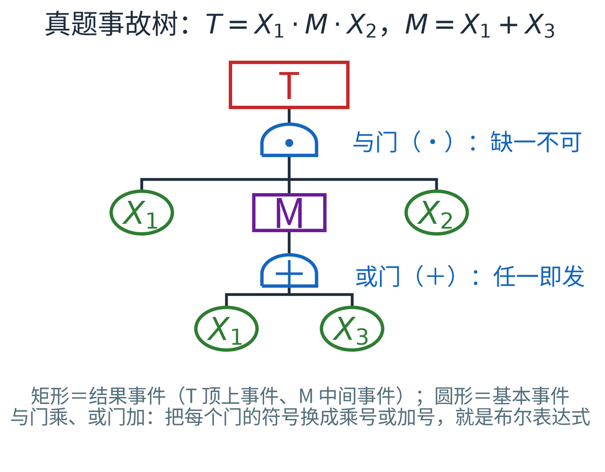

*读图顺序：顶上事件 → 门 → 中间事件 → 基本事件；与门乘、或门加。六套卷第四题都是这一题型，图由试卷给出、不给式子。*

## 真题解答（一）：写式、展开、化简

> 每一步都写清用了哪条布尔运算律——判分看的是过程，不是最后那一行。

| 步 | 做什么 | 式子 | 依据 |
| --- | --- | --- | --- |
| 1 | 中间事件写式 | $M=X_1+X_3$ | 或门：输入任一发生即发生 |
| 2 | 顶上事件写式 | $T=X_1\cdot M\cdot X_2$ | 与门：三个输入同时发生才发生 |
| 3 | 代入消去 $M$ | $T=X_1X_2(X_1+X_3)$ | 把第 1 步代入第 2 步 |
| 4 | 乘开 | $=X_1X_2X_1+X_1X_2X_3$ | 乘法对加法的分配律 |
| 5 | 幂等律 | $=X_1X_2+X_1X_2X_3$ | $X\cdot X=X$ |
| 6 | 吸收律 | $=X_1X_2(1+X_3)=X_1X_2$ | $A+AB=A$，且 $1+X=1$ |

- 结果：$T=X_1X_2$ —— 只剩 $X_1$、$X_2$ 的与关系，$X_3$ 被吸收
- 验算：取 $X_1=X_2=1$，无论 $X_3$ 取 0 还是 1，原树输出都是 1，说明 $X_3$ 与顶事件无关
- 考场写法：第 4、5、6 步各占一行，不要跳步；只写结果最多得 1/3 分

## 真题解答（二）：等效树、最小割集与采分点

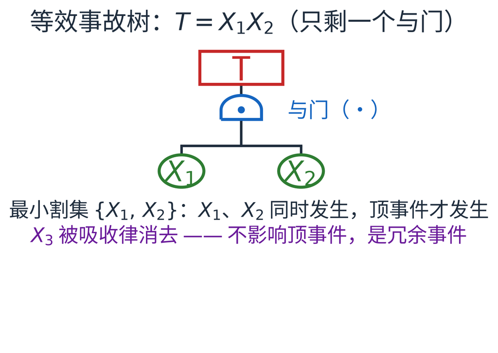

- 画树：$T$ 下接**一个与门**，两个输入 $X_1$、$X_2$；不能保留 $M$ 和 $X_3$
- 最小割集：$\{X_1,X_2\}$（只有一组二阶割集，没有一阶割集）
- 采分点：写式 3＋化简 3＋等效树 3＋结论 1 分；易错：只化简不画树、多报伪割集、把 $X_3$ 画进树里
- 工程含义：$X_1$、$X_2$ 是**串联屏障**，缺一不可；$X_3$ 不必投入整改资源
- 一句话：**与门乘、或门加；化简到最小割集，再照式子画树**

## 真题延伸：同一棵树算概率与重要度

- 六卷第四题只要求化简；若加一问“求 $P(T)$ 与重要度”，按四步作答
- 设 $q_1=0.02$、$q_2=0.03$、$q_3=0.10$，化简后 $T=X_1X_2$
- 正确：$P(T)=q_1q_2=0.02\times0.03=6.0\times10^{-4}$
- 错误：$P=0.02\times0.03\times(0.02+0.10-0.002)=7.08\times10^{-5}$，把重复的 $X_1$ 当独立事件
- 原因：布尔代数 $X_1\cdot X_1=X_1$；概率上同一事件不能乘两次，必须先化简
- 定义：$I_g(i)=P(T\mid x_i=1)-P(T\mid x_i=0)$，$I_c(i)=I_g(i)q_i/P(T)$
- 概率重要度：$I_g(1)=q_2=0.03$，$I_g(2)=q_1=0.02$，$X_1$ 更敏感
- 临界重要度：$I_c(1)=I_c(2)=1$——任一事件概率翻倍，顶事件概率也翻倍
- 结论：与门要两个条件同时成立，控住任一个即可阻断；或门任一发生即出事
- 管理含义：与门对应多重屏障，但每层都要维护；或门必须消除单点
- 考场写法：化简→代入→重要度→一句话结论

## 例题：统计指标与分级

**题目**：某机械厂平均职工 1200 人，全年实际总工时 $2.4\times10^{6}$ h；发生死亡事故 1 起（死亡 1 人）、重伤 2 人、轻伤 12 人，直接经济损失 900 万元。求千人死亡率、千人重伤率、百万工时伤害频率，并判定事故等级。

**解答**

- 千人死亡率 $=1/1200\times10^{3}=0.83$（人／千人）
- 千人重伤率 $=2/1200\times10^{3}=1.67$（人／千人）
- 百万工时伤害频率 $=(1+2+12)/(2.4\times10^{6})\times10^{6}=15/2.4=6.25$（人次／百万工时）
- 分级：死亡 3 人以下、重伤 10 人以下、直接经济损失 1000 万元以下 → **一般事故**
- 注意：若直接经济损失改为 1200 万元，就升为较大事故——三项判据只要有一项越线，就按更高的那一档认定

## 例题：事故树化简与最小割集 —— 题干与思路

练“树 → 布尔式 → 吸收 → 割集”的全链条，与考试第四题同型。

**已知**：$T$ 为顶上事件，$x_1\sim x_5$ 为基本事件，关系式为：

| 事件 | 关系式 | 事件 | 关系式 |
| --- | --- | --- | --- |
| $T$ | $M_1M_2$ | $M_3$ | $x_3x_5$ |
| $M_1$ | $x_1+M_3$ | $M_4$ | $M_5x_3$ |
| $M_2$ | $M_4+x_4$ | $M_5$ | $x_2+x_5$ |

**求**：① 写出 $T$ 的布尔式（不化简）；② 化简并列全部最小割集（按阶数排）；③ 指最薄弱环节与两条控制建议。

**公式**：与门 $T=x_1x_2\cdots x_n$、或门 $T=x_1+x_2+\cdots+x_n$；$x_i$ 为第 $i$ 个基本事件（1 发生／0 不发生）；吸收律 $A+AB=A$。

**路线**：① 由 $M_5$ 逐层往上代入 → ② 展开成乘积项 → ③ 吸收律删被包含项 → ④ 写割集、按阶数判薄弱。

## 例题：事故树化简与最小割集 —— 分步解答

**第 1 步 逐层代入**：$M_5=x_2+x_5$，$M_4=(x_2+x_5)x_3$，$M_2=M_4+x_4$，与 $M_1=x_1+x_3x_5$ 相乘，得 $T=(x_1+x_3x_5)[(x_2+x_5)x_3+x_4]$。

**第 2 步 展开**：$T=x_1x_2x_3+x_1x_3x_5+x_1x_4+x_2x_3x_5+x_3x_5+x_3x_4x_5$（共 6 项）。

**第 3 步 吸收**：含 $x_3x_5$ 的三项被 $x_3x_5$ 吸收，得 $T=x_1x_2x_3+x_1x_4+x_3x_5$。

**第 4 步 列割集**：$K_1=\{x_1,x_2,x_3\}$（三阶）、$K_2=\{x_1,x_4\}$（二阶）、$K_3=\{x_3,x_5\}$（二阶）；$K_2$ 最薄弱，$K_3$ 同为二阶须同步控制。

**判读**：全树无一阶割集，单点不致命；但 $x_1$ 在 $K_1$、$K_2$ 中都出现，优先切断 $x_1$ 或 $x_4$，其次 $x_3$、$x_5$。

**易错点／验算**：漏吸收会多报三个伪割集；取 $x_1=x_4=1$、其余为 0 时 $T=1$，去任一后 $T=0$，故 $K_2$ 确为最小割集。

## 真题变式：给定通报，自己建树

**题目**：某厂叉车在仓库通道撞伤一名行人。通报事实：①通道人车混行；②叉车限速器被拆除；③司机无证；④行人低头看手机；⑤仓库照明不足。请以“叉车撞人”为顶事件建树，写出布尔表达式并求最小割集。

- 顶层：与门——**人车在同一位置** 且 **叉车未能停下**
- 人因分支：行人闯入（看手机、无警示）、司机失误（无证、超速、视线受阻）
- 设备分支：制动失效、限速器被拆、喇叭失效
- 环境分支：照明不足、通道混行、堆料遮挡
- **怎么判断**：每层只写直接原因；门型用“缺一个还行不行”检验
- 产出：表达式 → 化简 → 最小割集 → 两条控制措施（人车分流、限速联锁）

## 例题：最小割集与顶事件概率 —— 题干与思路

练“先化简、再代概率”：同一基本事件在树里出现两次，概率不能乘两次。

**已知**：$T=M_1M_2$，$M_1=x_1+x_2$，$M_2=x_1+x_3$；基本事件独立，$q_1=0.1$、$q_2=0.2$、$q_3=0.05$。

**求**：① 化简 $T$，列全部最小割集并标阶数；② 求 $P(T)$（小数保留三位）；③ 指最薄弱环节与一条优先措施。

**公式**：或门 $P(x_i+x_j)=q_i+q_j-q_iq_j$，与门 $P(x_ix_j)=q_iq_j$；$q_i$ 为 $x_i$ 的发生概率（无量纲），$P(T)$ 为顶事件概率。

**路线**：① 布尔化简 → ② 写最小割集 → ③ 容斥代概率 → ④ 判单点失效。

## 例题：最小割集与顶事件概率 —— 分步解答

**第 1 步 化简**：$T=(x_1+x_2)(x_1+x_3)=x_1+x_1x_2+x_1x_3+x_2x_3$，吸收 $x_1x_2$、$x_1x_3$，得 $T=x_1+x_2x_3$。

**第 2 步 列割集**：$K_1=\{x_1\}$（一阶）、$K_2=\{x_2,x_3\}$（二阶）；$x_1$ 单点失效即致顶事件。

**第 3 步 求 $P(T)$**：$P(T)=q_1+q_2q_3-q_1q_2q_3=0.1+0.01-0.001=0.109$，即 $10.9\%$。

**第 4 步 判薄弱**：$x_1$ 贡献 $0.1/0.109\approx91.7\%$；优先消除单点，$x_2x_3$ 一路可设计冗余。

**判读**：有单事件割集的系统没有冗余——安全投入先消单点，再谈组合路径的冗余。

**易错点／验算**：不化简、把展开的四项当互斥直接相加得 $0.1+0.02+0.005+0.01=0.135$（偏高，$x_1$ 被加了两次）；两门独立直乘得 $0.28\times0.145=0.0406$（偏低，漏了共因）。以 $0.109$ 为准。

## 例题：LEC 风险分级 —— 题干与思路

练 $D=LEC$ 的取档、分级与排序：会算只是第一步，会排整改优先级才算会。

**已知**：5 个工位按 LEC 表取值（$L$、$E$、$C$ 均为查表档位，无量纲）：

| 工位 | $L$ | $E$ | $C$ |
| --- | --- | --- | --- |
| 冲压上料 | 6 | 6 | 15 |
| 喷漆房 | 1 | 6 | 40 |
| 叉车转运 | 3 | 3 | 15 |
| 焊接打磨 | 3 | 6 | 7 |
| 装配 | 0.5 | 6 | 3 |

**求**：① 各工位 $D$（取整）并分级；② 排整改优先级；③ 给降分三条路。

**公式**：$D=L\times E\times C$，$L$ 事故可能性（0.1～10）、$E$ 暴露频繁程度（0.5～10）、$C$ 后果严重度（1～100），均无量纲。

**路线**：① 乘出 $D$ → ② 查阈值定级 → ③ 降序排 → ④ 给降分方案。

## 例题：LEC 风险分级 —— 分步解答

**第 1 步 算 $D$**：冲压 $6\times6=36$，$36\times15=540$；其余同法：喷漆 $6\times40=240$、叉车 $9\times15=135$、焊接 $18\times7=126$、装配 $3\times3=9$。

**第 2 步 分级**：$540>320$ 极其危险；$240\in[160,320]$ 高度危险；$135$、$126\in[70,160]$ 显著危险；$9<20$ 稍有危险。

**第 3 步 排优先级**：冲压 540 ＞ 喷漆 240 ＞ 叉车 135 ＞ 焊接 126 ＞ 装配 9；先处理 $D>320$，再处理 $160\sim320$。

**第 4 步 给降分路**：降 $L$（联锁、自动上料）、降 $E$（减少暴露工时、远程操作）、降 $C$（防护罩、急停、PPE），按工程优先。

**判读**：$D=540$ 的冲压上料须立即整改；喷漆房溶剂蒸气暴露频繁，属限期整改。

**易错点／验算**：注意阈值边界（320、160、70、20 的含否）；$E$ 是暴露频繁程度不是暴露时间，$C$ 按最严重后果取档；验算排序与 $D$ 大小一致、五档无遗漏。

## 例题：事故损失与安全投入 —— 题干与思路

练“把安全投入算成两本账”：口径不同，结论会相反。

**已知**（间接损失＝直接损失×4，一次性投入 60 万元）：

| 项目 | 不投防护 | 投防护 |
| --- | --- | --- |
| 年事故起数／起 | 4 | 1 |
| 单起直接损失／万元 | 2 | 2 |
| 年维护费／万元 | 0 | 3 |

**求**：① 单起总损失与不投防护的年损失；② 投防护后的年净收益与回收期（保留 1 位）；③ 只算直接损失时的回收期。

**公式**：总损失 $C=C_d(1+k)$；年净收益 $N=S_0-S_1-F$；回收期 $T_p=I/N$（$C_d$ 直接损失、$S_0$／$S_1$ 年损失、$F$ 维护费、$I$ 投入，单位万元）。

**路线**：① 算单起总损失 → ② 算两口径年损失 → ③ 算净收益与回收期 → ④ 比两本账。

## 例题：事故损失与安全投入 —— 分步解答

**第 1 步 求单起总损失**：$C=2\times(1+4)=10$ 万元；不投防护年损失 $S_0=4\times10=40$ 万元。

**第 2 步 求年净收益**：投防护年损失 $S_1=1\times10=10$ 万元，年避免 $40-10=30$ 万元；扣维护 3 万元，得 $N=27$ 万元。

**第 3 步 求回收期**：$T_p=60/27=2.22\approx2.2$ 年（约 27 个月）。

**第 4 步 只算直接损失的对照**：年避免 $3\times2=6$ 万元（起数 4−1＝3），净 $6-3=3$ 万元，$T_p'=60/3=20$ 年。

**判读**：安全投入值不值几乎全由“间接损失算不算”决定；只算直接损失会把该投的防护误判为不划算。4 倍须用本厂台账校准，停产、处罚、保险等收益未计入。

**易错点／验算**：间接是直接的 4 倍，总损失是 5 倍不是 4 倍；投入一次性、维护每年；验算 $27\times2.2\approx60$。

## 讨论题：安全投入值不值

**情境**：某车间拟投入 80 万元加装机器人安全围栏与光栅，预计可消除该类机械伤害。近三年该车间发生轻伤 6 起、无重伤，单起轻伤平均损失（医疗 + 停工 + 赔偿）约 3 万元。

- 直接账：年化避免损失约 $6\times3/3=6$ 万元／年，静态回收期约 $80/6\approx13.3$ 年——**算不过来**
- 但还要算：重伤／死亡的小概率大后果、停工损失、监管处罚、刑事责任、品牌与订单损失、员工士气
- 关键问题：**人的生命与健康能不能折成钱？** 如果能，用什么口径（人力资本法、支付意愿法、法定赔偿标准）？

> 安全投入的决策，本质上是“用确定的钱，去对冲不确定的灾难”。

## 讨论题：责任文化怎么建

**情境**：某厂实行“安全事故零容忍”，一旦发生事故，班组全员扣奖金，车间主任免职。结果：轻伤与未遂事故**大幅瞒报**，直到发生一起重伤才暴露。

- 问题出在指标设计：把“事故数”当考核指标，必然激励瞒报
- 改进方向：

| 做法 | 作用 |
| --- | --- |
| 未遂事故主动上报免罚、瞒报重罚 | 让坏消息流动起来 |
| 报告数量纳入正向激励 | 鼓励暴露隐患 |
| 事故调查对事不对人 | 找系统原因而非找替罪羊 |
| 整改闭环可追溯 | 防止“报告了没人管” |

- 与第 3 讲 PDCA、第 7 讲 8D 的 D7（预防再发）同一逻辑：**闭环比追责更重要**

## 课堂讨论：安全 vs 效率

- 情境：订单提前 15 天交付，车间提出“先拆光栅提节拍，交付后再装回”
- 效率账：节拍 12→15 件／分（+25%）；延期违约金按合同约 80 万元

| 立场 | 核心主张 | 账怎么算 | 盲点 |
| --- | --- | --- | --- |
| 生产派 | 先交付，后补防护 | 违约金、客户、现金流 | 把伤害当成小概率 |
| 安全派 | 安全设施不能拆 | 法规、事故损失、刑责 | 缺替代方案，易僵持 |
| 工程派 | 先评估，再定临时措施 | 风险降低与节拍损失 | 评估要时间，可能贻误 |

- 冲突本质：确定且近期的收益 vs 不确定且远期的灾难
- 三个追问：谁批准？拆除期怎么控？谁验收恢复？
- 折中：不拆光栅，改双人上料、降速运行、临时围栏＋旁站
- 判据：“临时”必须有期限、责任人、验收，否则临时会变长期
- 底线：不得以赶工期为由违反强制性标准；安全设施不得擅自拆除、停用
- 结论：效率可以谈判，不可逆的伤害不能

## 课堂讨论：AI 监测能否替代人的判断

- 情境：AI 视频监测识别未戴安全帽、闯入危险区、明火烟雾，准确率 98%
- 设漏报率 2%：2% × 10 万次／年 ＝ 2000 次；误报多了，现场会关掉告警
- 误报与漏报要分开定价：漏报赔的是事故，误报赔的是信任
- 训练数据要覆盖夜班、逆光、雨雾；模型更新后必须重新验收

| 环节 | AI 能做 | 人必须做 |
| --- | --- | --- |
| 发现 | 7×24 识别、回溯、把未遂变数据 | 复核异常、判断真伪 |
| 判断 | 模式匹配、分级告警 | 因果与意图判断、现场确认 |
| 处置 | 提示、联锁、留痕 | 停工决策、对外担责 |

- 三个能力边界：分布外新风险、意图与因果、法律责任
- 判据：可解释、可验证、可追责，才配做“最后一道防线”
- 结论：AI 替代的是巡检的眼睛，不是负责的人

## 环保简答：三废、清洁生产与双碳

- 5 分简答骨架：定义 1 分＋要点 3 分＋例子 1 分
- 三废口径：废气、废水、废渣；噪声单列，危废在固废中单管

| 主题 | 必答要点（3 分） | 现场例子 |
| --- | --- | --- |
| 三废治理 | 废气按污染物选工艺；废水预处理—生化—深度；固废减量化—资源化—无害化 | 焊烟净化、涂装废水生化、铝屑回收 |
| 清洁生产 | 源头削减优先，过程控制其次，末端治理最后；审核七阶段 | 水性漆替代溶剂漆、余热回收 |
| 双碳 | 2030 年前碳达峰、2060 年前碳中和；节能提效、能源替代、工艺替代、碳市场 | 屋顶光伏、绿电采购、再生铝 |

- 清洁生产：2003 年 1 月 1 日《清洁生产促进法》施行，核心是“源头削减”
- 一句话：三废讲“怎么治”，清洁生产讲“怎么少产生”，双碳讲“怎么把碳变成成本”

## 开放问题：智能工厂的安全边界

- 无人化是否等于更安全？——减少人暴露，但把风险集中到设备、网络与算法
- 三个待答问题：
1. **责任边界**：算法误判导致事故，责任在算法供应商、集成商还是使用企业？
2. **可解释性**：安全 AI 给出“高风险”告警却无法解释原因，现场该不该停线？
3. **人机信任**：过度信任自动安全系统（自动化偏见）与完全不信任，哪个更危险？
- 一条底线：**任何自动安全系统都必须有独立于它的最后一道物理防护**（本质安全）
- 一个判据：当 AI 失效时，系统是否仍处于安全状态（失效—安全原则）

## AI 提问：本讲 5 个延伸问题

- 同一棵树按结构／概率／临界重要度排序，何时不一致？给算例
- 把“赶工期拆光栅”写成约束优化：工期、成本、风险怎么设？
- 涂装线“安全—环保—成本”三目标权衡：数据从哪来？
- AI 监测漏报率 2% 如何定价？误报／漏报成本怎么定阈值？
- 选一份事故报告，把直接、间接、管理原因映射到基本事件
- 每条都要来源：法规、标准、调查报告、论文；标注口径与年份
- 先让 AI 给框架，数值必须能手算或 Python 复核
- 交叉核对官方报告与媒体报道、标准原文与二手解读
- 评分：可验证 40%、可追溯 30%、有适用条件 30%

## 考前自测：10 道判断题

> 上一页留了五个延伸问题；这一页把本讲要点收成 10 道判断题。

| # | 判断 | 答案与依据 |
| --- | --- | --- |
| 1 | 安全是绝对的，达标即无风险 | ×：安全是相对概念 |
| 2 | 事故等级取死亡、重伤、损失最高项 | √：三者取最高 |
| 3 | 重伤事故前有大量未遂与轻伤 | √：1∶29∶300 |
| 4 | 事故树与门：任一输入发生则输出 | ×：那是或门 |
| 5 | 布尔化简 $X+XY=X$ 用吸收律 | √：$A+AB=A$ |

| # | 判断 | 答案与依据 |
| --- | --- | --- |
| 6 | 最小割集阶数越低越危险 | √：阶数低更易发生 |
| 7 | LEC 的 $D$ 值越大风险越低 | ×：D 越大越危险 |
| 8 | 间接损失不必计入事故总损失 | ×：间接损失也要算 |
| 9 | 清洁生产就是建好末端治理 | ×：源头削减优先 |
| 10 | 双碳：2030 中和、2060 达峰 | ×：顺序颠倒 |

- 答案：1× 2√ 3√ 4× 5√ 6√ 7× 8× 9× 10×
- 重点：第 4 题与门／或门；第 8 题间接损失；第 9 题源头优先；第 10 题双碳顺序
- 自测：8 题以上合格；错 3 题以上回对应页复读
- 易混：安全相对性 vs 标准；割集阶数 vs 数量；LEC 半定量 vs FTA 定量

# 第六部分 · 本讲小结、作业与下讲预告

- 小结：安全可度量、风险可计算、责任可追溯、环境可治理
- 作业 3 题（100 分）：概念 1 题、计算 1 题两问、分析 1 题
- 下讲预告：成本管理与人力资源——把安全与环境算进成本
- 课后：把本讲的安全/环境问题带回你的课程设计选题
- **承上**：上一部分用例题与讨论把算与判练完；本部分要回答“本讲记住什么、课后做什么、下讲学什么”——五条主线、20 个术语、100 分作业与第 5 讲预告。

## 本讲小结：五条主线

> 上一部分收在例题与讨论；这一页把整讲收成五条主线，从安全语言一路收回到环境代价。
1. 安全是**相对概念**，其标准是社会对风险的接受度；事故分四级，判定取死亡、重伤、损失三者中最高者。
2. **海因里希法则** 1 : 29 : 300 表明事故是隐患累积的结果，安全工作必须前移；能量意外释放论把风险归结为**两类危险源**。
3. **事故树**用演绎法建树、布尔代数化简、最小割集找薄弱环节、顶事件概率定投入优先级；这是安全工程最像“计算”的部分。
4. 责任判定看“是否本可避免”：**安全事故**可能源于不可抗力，**安全责任事故**源于应尽而未尽的义务；五方责任主体各有法定边界。
5. 环保的本质是把**外部成本内部化**：环评与“三同时”前置约束，三废治理按污染物选工艺，清洁生产优先于末端治理，双碳目标把排放变成成本。
- 主线回收：能量 → 危险源 → 事故树 → 责任 → 环境；两句判据：**算得清的风险才管得住，说得清的代价才分得清责任**。
- 过渡：第 5 讲把事故损失与环境成本折成现金流；自测——合上笔记 90 秒复述五条，各补一个本讲数字

## 关键概念清单：20 个术语

| 安全语言 | 风险计算 | 责任与安全 | 环境工程 |
| --- | --- | --- | --- |
| 危险源 | 安全检查表 | 五方责任 | 环境影响评价 |
| 两类危险源 | LEC | 安全事故 | 三同时 |
| 海因里希法则 | 事故树 | 安全责任事故 | 清洁生产 |
| 未遂事故 | 最小割集 | 四不放过 | 外部性 |
| 事故分级 | 最小径集 | 安全网络 | 碳达峰碳中和 |

- 四组关系：安全语言答“什么是危险”，风险计算答“先治哪里”，责任答“谁来担”，环境答“代价谁付”
- 会算会判：$D=LEC$ 定级、事故树化简与最小割集；事故四级、责任事故判据、环评三类
- 抽查：下次课随机抽 5 个术语，各配一句定义与一个现场例子

## 缩写速查：安全、环保与标准

| 缩写 | 英文全称 | 中文 |
| --- | --- | --- |
| EHS | Environment, Health and Safety | 环境、健康、安全 |
| OHSMS | Occupational Health and Safety Management System | 职业健康安全管理体系 |
| LEC | Likelihood, Exposure, Consequence | 作业条件危险性评价（$D=LEC$） |
| FTA | Fault Tree Analysis | 事故树分析 |
| SCL | Safety Checklist | 安全检查表 |
| JHA | Job Hazard Analysis | 工作危害分析 |
| HAZOP | Hazard and Operability Study | 危险与可操作性分析 |
| PPE | Personal Protective Equipment | 个体防护装备 |

| 缩写 | 英文全称 | 中文 |
| --- | --- | --- |
| EMS | Environmental Management System | 环境管理体系 |
| EIA | Environmental Impact Assessment | 环境影响评价 |
| VOC | Volatile Organic Compounds | 挥发性有机物 |
| COD | Chemical Oxygen Demand | 化学需氧量 |
| GHG | Greenhouse Gas | 温室气体 |
| GJB | Guojia Junyong Biaozhun | 国家军用标准 |
| HLS | High Level Structure | 高阶结构（管理体系标准统一骨架） |
| GB／T | Guobiao Tuijianxing | 国家标准（GB 强制）／推荐性国标（T＝推荐，自愿采用） |

- ① 单选常考“体系归属”：9000 质量、14000 环境、45001 职业健康安全
- ② LEC 三个字母就是三个因子，别与“风险矩阵”混
- ③ 军标 GJB 与国标 GB 并列，合同引用即强制

## 作业：概念、计算与分析（100 分）

**1. 概念题（20 分）** 辨析五组概念，各举一例（每组 4 分）：安全事故／安全责任事故、海因里希法则／能量意外释放论、最小割集／最小径集、安全检查表／LEC、清洁生产／末端治理。

**2. 计算题（50 分）**（1）某厂 1500 人、总工时 $3.0\times10^{6}$ h，死亡 1、重伤 3、轻伤 20 人，损失 900 万元：求千人死亡率、千人重伤率、百万工时伤害频率并定级；损失 1200 万元时如何变（20 分）。

**（2）** $T=M_1M_2$，$M_1=x_1+x_3x_4$，$M_2=x_2+x_3+x_5$，$q_1=q_3=q_5=0.1$、$q_2=q_4=0.2$：化简求最小割集、定最薄弱环节，近似求顶事件概率（30 分）。

**3. 分析题（30 分）** 冲压冲手事故：① 按 $L=3$、$E=6$、$C=15$ 算 $D$ 并定级，加光栅与自动上下料后 $L=1$、$E=3$ 的等级（10 分）；② 判安全事故还是责任事故，指出责任主体（10 分）；③ 写废切削液与含油废水的治理路线，判断是否需环评（10 分）。

- 评分与提交：计算写公式、代值与单位，按步骤给分；下次课前交纸质版，第 3 题抽 2 人各讲 3 分钟。

## 思考题：三个开放问题

- 企业安全投入已达标，仍因员工故意违章发生事故，企业该不该承担主要责任？
- “零事故”目标与“零瞒报”目标，哪个更接近真正的安全？
- 环境成本内部化后，产品价格上涨，低收入消费者承担更大比例——这是公平的吗？
- 三个问题分别指向：责任与过错程度、指标设计、分配公平
- 回答要求：先给立场，再给判据，最后给一个本讲的概念或数字作证据
- 下讲接口：安全投入值不值、人的价值能否折算，第 5 讲接着算

## 下讲预告：成本管理与人力资源

| 模块 | 核心内容 | 你要会什么 |
| --- | --- | --- |
| 成本构成 | 直接／间接、固定／变动、制造费用 | 把一笔支出归到对的类 |
| 成本指标 | 库存周转率、量本利分析、ABC 成本法 | 算周转率与盈亏点 |
| 技术经济评价 | 现金流量表、回收期、NPV、IRR | 算一道投资回收期 |
| 成本驱动设计 | 全生命周期成本、质量成本 | 说明“设计定成本” |
| 人力资源 | 岗位能力模型、人机协作、绩效激励 | 画一张能力模型 |

- 衔接：本讲的事故损失、环境成本、安全投入，第 5 讲都要折成现金流进 NPV 与回收期
- 主线：安全讲“别出事”，成本讲“别白花钱”——两笔账要并到一张表上算
- 伦理落点：成本与安全的取舍、人的价值能否折算、分配公平
- 课前准备：预习 3.4；带计算器；预习现金流量表与静态投资回收期

## 课后阅读与预习清单

- **教材**：3.3 安全工程（p174–184）——安全体系、事故分级、能量论、事故树、安全网络；环保看课件。
- **课件**：3.3 安全工程20231015（事故树与最小割集）、3.3安全工程-王佳辰（实例）、3.1 环保工程20230529（三废与环评）。
- **法规与标准**：安全生产法、建设工程安全生产管理条例；环境保护法、环境影响评价法；ISO 9001／14001／45001。
- **预习**：3.4 成本管理（p185–193）——公司类型与责任、制造费用、库存周转率、投资回收期、NPV／IRR。
- **三个预习问题**：① 事故损失为什么计入成本而非“营业外支出”？② 安全投入的回收期怎么算？③ 环境成本内部化后谁吃亏？
- **提交**：1 页阅读笔记（3 问＋1 疑），下次课带来。
- 一句话：**带着问题读书，比读完再找问题有用得多。**